# Reflections on NY Phil – The NY Phil as a lens on changes in US society

Around the turn of the century, New York City became the arts center of the world. Its establishment not only encouraged the flourishing of American musicians but also attracted musicians from all over the world to NYC. NY Philharmonic as an important art and culture institution, reflects the social and economic changes of the United States society over time. In this study I focus on NY Philharmonic data from three perspectives: 1. the contemporality and the economic change of the US; 2. the nationality of composers whose works are performed by NY Philharmonic in relation to the political enviroments of the US; 3. the rise of women composers over time

### 1. Getting data from NY Philharmonic’s github page

First of all, I read the XML file from NY Philharmonic’s github page (https://github.com/nyphilarchive/PerformanceHistory/blob/master/Programs/complete.xml) and found the number of every composers in all season and put them in a table.

```r
require("XML")
require(mosaic)
xmlfile <- xmlParse("complete.xml",encoding="UTF-8")
rootnode = xmlRoot(xmlfile) #gives content of root

incrementComp <- function(composer_stats, c, season){
  if (is.null(composer_stats[c, season])) {
    composer_stats[c, season] <- 1
  } else if (is.na(composer_stats[c,season])) {
    composer_stats[c, season] <- 1
  } else {
    composer_stats[c, season] <- composer_stats[c, season] + 1
  }
  return(composer_stats)
}

composerBySeasonComplete <- data.frame()
for (seas in 1:xmlSize(rootnode)) {
  # DEBUG: cat(seas, "\n")
  firstlist <- xmlToList(rootnode[[seas]])
  season <- firstlist$season
  season <- paste("Season",season,sep=".")
  works <- firstlist$worksInfo
  if (is.list(works)) {     # sometimes works is actually empty
      for (i in 1:length(works)) {
        if (!is.null(works[[i]]$composerName)) {    #sometimes there is no composer
          composerBySeasonComplete <- incrementComp(composerBySeasonComplete, works[[i]]$composerName,season)
        }
      }
    }
}
colnames(composerBySeasonComplete)[1]="composers"
write.csv(composerBySeasonComplete, "composerBySeasonComplete.csv")
```

the cleaned data look like:

```r
composerBySeasonComplete <- read.csv("composerBySeasonComplete.csv", row.names=1, encoding="UTF-8")
composerBySeasonComplete[1:5,1:5]
```

```
##                    composers Season.1842.43 Season.1843.44 Season.1844.45
## 1    Beethoven,  Ludwig  van             12              4              8
## 2    Weber,  Carl  Maria Von             10              6              6
## 3            Hummel,  Johann              8              6              2
## 4        Rossini,  Gioachino              8              2             NA
## 5 Mozart,  Wolfgang  Amadeus              4              4              2
##   Season.1845.46
## 1              6
## 2              6
## 3             NA
## 4              6
## 5              6
```

To get a general sense of the data, I decide to order composers by the number of works that got performed in descending order.

```r
SumComp=rowSums(composerBySeasonComplete[2:175],na.rm=TRUE)
SumComp=cbind(composerBySeasonComplete[1],SumComp)
SumComp1=SumComp[order(-SumComp$SumComp),]
```

The following graph shows that most of the composers’ works got performed fewer than ten times, and only 16 composers’ works are performed more than 1000 times. Therefore, I expect the composers are very diverse.

```r
require(mosaic)
nrow(SumComp1)
```

```
## [1] 2652
```

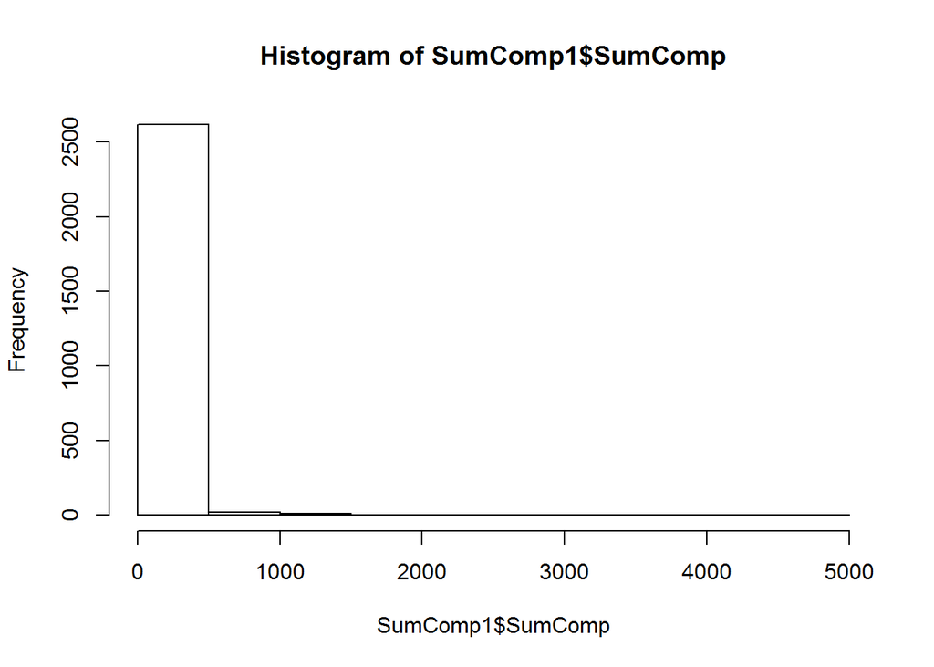

```r
hist(SumComp1$SumComp)
```

```r
comp1000=filter(SumComp1,SumComp>=1000)
nrow(comp1000)
```

```
## [1] 16
```

```r
comp1000
```

```
##                          composers SumComp
## 1                 Wagner,  Richard    4942
## 2          Beethoven,  Ludwig  van    4509
## 3      Tchaikovsky,  Pyotr  Ilyich    3710
## 4       Mozart,  Wolfgang  Amadeus    2632
## 5                Brahms,  Johannes    2528
## 6                Strauss,  Richard    1624
## 7              Mendelssohn,  Felix    1514
## 8                 Berlioz,  Hector    1396
## 9         Bach,  Johann  Sebastian    1377
## 10 Dvorak,  Anton¨ªn    1212
## 11               Gershwin,  George    1129
## 12                Schubert,  Franz    1124
## 13                 Ravel,  Maurice    1087
## 14              Prokofiev,  Sergei    1087
## 15               Stravinsky,  Igor    1085
## 16                Debussy,  Claude    1077
```

```r
compl1000=filter(SumComp1,SumComp<=10)
nrow(compl1000)
```

```
## [1] 2284
```

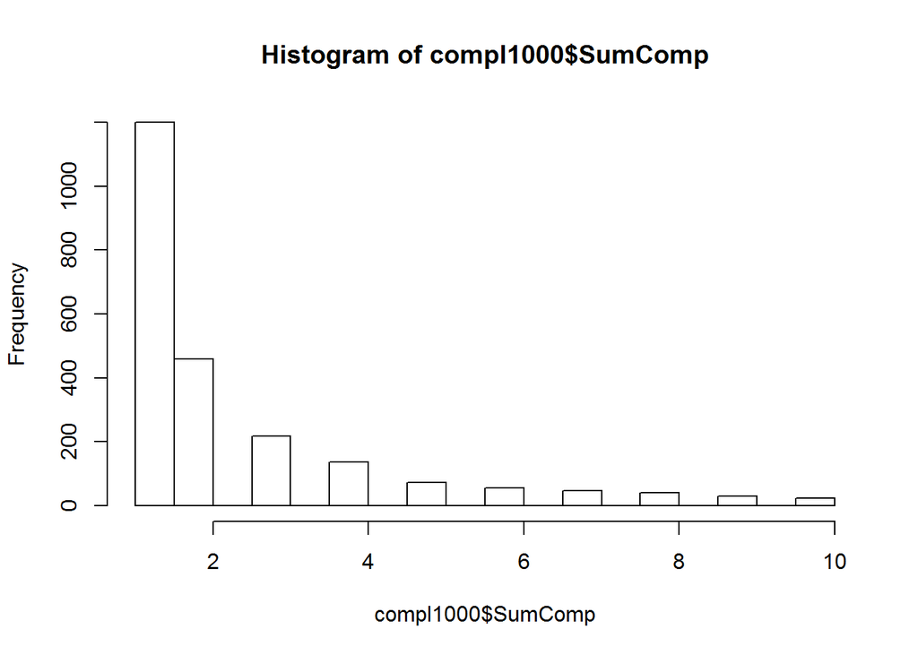

```r
hist(compl1000$SumComp)
```

### 2.Computing popularity score

Graph of number of performance per year

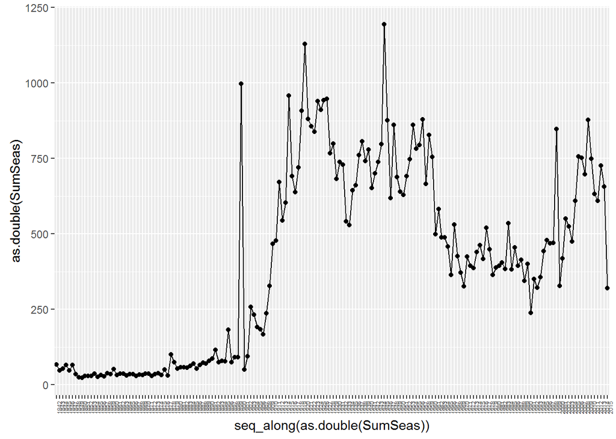

```r
SumSeas=colSums(composerBySeasonComplete[2:175],na.rm=TRUE)
require(ggplot2)
qplot(seq_along(as.double(SumSeas)),as.double(SumSeas))+geom_line()+scale_x_discrete(labels =(1842:2015))+ theme(axis.text.x = element_text(angle = 90,size=5, hjust = 1))
```

Because the number of performance change year by year, I computed a “popularity score” to normalize by total number of performances. I got the popularity score by dividing the number of performances for each composers in each season by the total number of performance in each season.

```r
require(base)
composerBySeasonComplete[is.na(composerBySeasonComplete)] <- 0
composerBySeasonComplete1=composerBySeasonComplete[2:175]
composerBySeasonComplete2=composerBySeasonComplete[1]
popScoreComposerComplete=data.frame()
totalNumConcert=colSums(composerBySeasonComplete1, na.rm=TRUE)
for ( i in 1:2652){
  popScoreComposerComplete[i,]=composerBySeasonComplete1[i,]/totalNumConcert
  i=i+1
}
popScoreComposerComplete=cbind(composerBySeasonComplete2,popScoreComposerComplete)
write.csv(popScoreComposerComplete,"popScoreComposerComplete.csv")
```

the popularity score table looks like:

```r
popScoreComposerComplete <- read.csv("~/GitHub/azhangproject/popScoreComposerComplete.csv", row.names=1, encoding="UTF-8")
popScoreComposerComplete[1:5,1:5]
```

```
##                    composers Season.1842.43 Season.1843.44 Season.1844.45
## 1    Beethoven,  Ludwig  van     0.17647059     0.08333333     0.14814815
## 2    Weber,  Carl  Maria Von     0.14705882     0.12500000     0.11111111
## 3            Hummel,  Johann     0.11764706     0.12500000     0.03703704
## 4        Rossini,  Gioachino     0.11764706     0.04166667     0.00000000
## 5 Mozart,  Wolfgang  Amadeus     0.05882353     0.08333333     0.03703704
##   Season.1845.46
## 1     0.09090909
## 2     0.09090909
## 3     0.00000000
## 4     0.09090909
## 5     0.09090909
```

the top twenty list in the popularity score table does not differ much from the composers by season table.

```r
popScoreSumComp=rowSums(popScoreComposerComplete[2:175],na.rm=TRUE)
popScoreSumComp=cbind(popScoreComposerComplete[1],popScoreSumComp)
popScoreSumComp1=popScoreSumComp[order(-popScoreSumComp$popScoreSumComp),]
#test1=rowSums(popScoreSumComp1$popScoreSumComp)
head(popScoreSumComp1,20)
```

```
##                                           composers popScoreSumComp
## 1                           Beethoven,  Ludwig  van       14.753295
## 81                                 Wagner,  Richard       11.688653
## 5                        Mozart,  Wolfgang  Amadeus        7.586044
## 15                              Mendelssohn,  Felix        6.992933
## 163                     Tchaikovsky,  Pyotr  Ilyich        6.991802
## 119                               Brahms,  Johannes        4.885748
## 50                                Schumann,  Robert        4.197614
## 2                           Weber,  Carl  Maria Von        4.073181
## 37                                 Berlioz,  Hector        3.882389
## 98                                    Liszt,  Franz        3.574857
## 56                                 Schubert,  Franz        3.472880
## 122                        Bach,  Johann  Sebastian        3.287059
## 205                               Strauss,  Richard        2.885479
## 189                 Dvorak,  Anton¨ªn        2.624591
## 14                            Haydn,  Franz  Joseph        2.249149
## 39  Chopin,  Fr¨¦d¨¦ric        2.009401
## 74                        Handel,  George  Frideric        2.007217
## 674                              Prokofiev,  Sergei        1.965981
## 770                               Gershwin,  George        1.928257
## 507                               Stravinsky,  Igor        1.900496
```

```r
require(stringr)
```

```r
popScoreComposerComplete$composers=str_replace_all(popScoreComposerComplete$composers,"[^[:graph:]]", " ")
popScoreComposerComplete$composers=gsub("  ", " ", popScoreComposerComplete$composers, fixed = TRUE)

composerBySeasonComplete$composers=str_replace_all(composerBySeasonComplete$composers,"[^[:graph:]]", " ")
composerBySeasonComplete$composers=gsub("  ", " ", composerBySeasonComplete$composers, fixed = TRUE)
```

# 3. The contemporality of NY Philharmonic reportories and the change of US economy

Even though NY Philharmonic is a classical music institution, it is still important for it to not only play established composers’ works but also play contemporary composers’ work. Especially, the composer in residence program at NY philharmonic shows that NY philharmonic is working on promoting living composers’ works.

Only at economically stable and affluent times are people able to invest on music and art education. This will increase the number of contemporary composers. With the additional sources of new music we should see this reflected by a relative increase in the proportion of works by contemporary rather than deceased composers being performed. Therefore, we should look for relationships between US economic measurements like GDP and the proportion of contemporary works performed.

For this part, I am scraping wikipedia pages. The web pages’ structures for different time periods are different. I scraped the classical era composer’s birth and death year page (https://en.wikipedia.org/wiki/List_of_Classical-era_composers) in python with the following code.

```r
library(png)
```

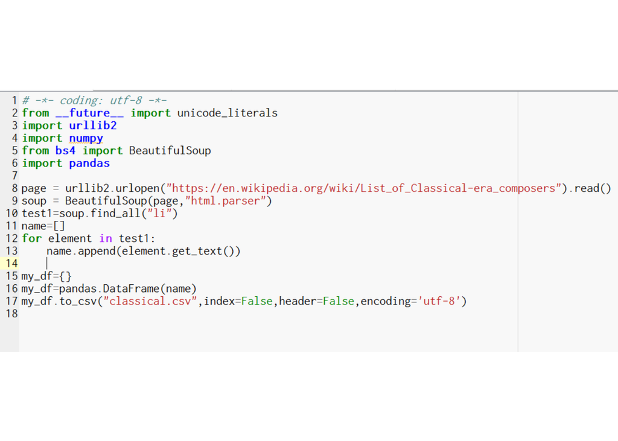

```r
library(grid)
img04 <- readPNG("classicalCode.png")
grid.raster(img04)
```

```r
classical=read.csv("classical.csv",header=FALSE,encoding="UTF-8")
classical1=strsplit(as.character(classical$V1)," ")
year=list(rep(0,length(classical1)))
for (i in 1: length(classical1)){
  year[i]=classical1[[i]][length(classical1[[i]])]
}

yearD=list(rep(0,length(classical1)))
for (i in 1:length(year)){
  yearD[i]=paste(strsplit(year[[i]],"")[[1]][7],strsplit(year[[i]],"")[[1]][8],
  strsplit(year[[i]],"")[[1]][9],strsplit(year[[i]],"")[[1]][10],sep = "")
}
Year.of.death=unlist(yearD)

Name1=list(rep(0,length(classical1)))
for (i in 1:length(classical1)){
  name=classical1[[i]][1:length(classical1[[i]])-1]
  Lname=name[length(name)]
  Fname=name[1:length(name)-1]
  Fname=paste(as.list(Fname), collapse=" ")
  FullName=paste(c(as.list(Lname),as.list(Fname)),collapse=", ")
  Name1[i]=FullName
}
classical3=cbind(Year.of.death,Name1)
classical3=as.data.frame((classical3))
classical4=suppressWarnings(subset(classical3,Year.of.death>=1842))
```

I use rvest to scrape the page for romantic era composers page(https://en.wikipedia.org/wiki/List_of_Romantic-era_composers), twentieth century composers’ page(https://en.wikipedia.org/wiki/List_of_20th-century_classical_composers), and twenty first century composers’ page (https://en.wikipedia.org/wiki/List_of_21st-century_classical_composers).

```r
require(mosaic)
library(rvest)
url <- 'https://en.wikipedia.org/wiki/List_of_20th-century_classical_composers'
html <- read_html(url, encoding = "UTF-8")
tables <- html_table(html, fill=TRUE)
tables=tables[[2]]
tables=tables[1:3]
tables$Name=str_replace_all(tables$Name,"[^[:graph:]]", " ")
for (i in 1:nrow(tables)){
  test=unlist(strsplit(tables$Name[i],""))
  n=(length(test)+1)/2
  test1=test[1:n]
  test2=do.call(paste, c(as.list(test1), sep=""))
  tables$Name1[i]=test2
}
twentiethC=tables[2:4]
```

```r
url <- 'https://en.wikipedia.org/wiki/List_of_21st-century_classical_composers'
html <- read_html(url, encoding="UTF-8")
tables <- html_table(html, fill=TRUE)
tables=tables[[2]]
tables=tables[1:3]
for (i in 1:nrow(tables)){
  test=unlist(strsplit(tables$Names[i],""))
  n=(length(test)+1)/2
  test1=test[1:n]
  test2=do.call(paste, c(as.list(test1), sep=""))
  tables$Name1[i]=test2
}
twentyfirstC=tables[2:4]
```

```r
twentiethC <- read.csv("twentiethC.csv",row.names=1, encoding="UTF-8")
twentiethCS=twentiethC[2:3]
twentiethCS$"Year.of.death"=as.character(twentiethCS$"Year.of.death")
twentiethCS$"Year.of.death"[is.na(twentiethCS$"Year.of.death")]=2016
dyear=rbind(classical4,twentiethCS)

twentyfirstC <- read.csv("twentyfirstC.csv",row.names=1,header=FALSE,encoding="UTF-8")
twentyfirstC$V3=as.character(twentyfirstC$V3)
twentyfirstC$V3[is.na(twentyfirstC$V3)]=2016
names(twentyfirstC)[names(twentyfirstC)=="V3"] <- "Year.of.death"
twentyfirstC=twentyfirstC[2:3]
names(twentyfirstC)[names(twentyfirstC)=="V4"] <- "Name1"
dyear=rbind(dyear,twentyfirstC)
```

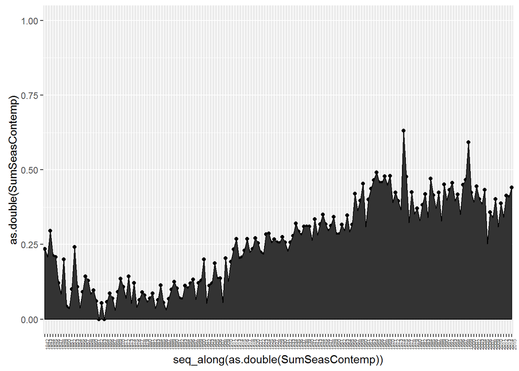

```r
comp=composerBySeasonComplete[2:175]
test=list(rep(0, nrow(comp)))
for (i in 1: nrow(comp)){
    test[i]<- min(which(!is.na(comp[i,])))
}
test=unlist(test)

firstPerf=colnames(comp)[test]

firstPerf1=list(rep(0, nrow(comp)))
for (i in 1:length(firstPerf)){
  firstPerf1[i]=(unlist(strsplit(firstPerf[i],"\\."))[2])
}
firstPerf1=unlist(firstPerf1)
Name1=as.character(composerBySeasonComplete$composers)
compContemp=as.data.frame(cbind(Name1,firstPerf1))

test=merge(compContemp,dyear)
l=c()
for (i in 1:nrow(test)){
  if (as.numeric(test[i,2])<as.numeric(test[i,3])){
    l=c(l,i)
  }
}
contempComp=test[l,]
contempComp=contempComp$Name1

l=c()
for (i in 1:length(contempComp)){
  l=c(l,which(contempComp[i]==popScoreComposerComplete$composers))
}
contem=unique(popScoreComposerComplete[l,])
SumSeasContemp=colSums(contem[2:175],na.rm=TRUE)
qplot(seq_along(as.double(SumSeasContemp)),as.double(SumSeasContemp))+ylim(0,1)+geom_area(colour="black")+geom_line()+scale_x_discrete(labels =(1842:2015))+ theme(axis.text.x = element_text(angle = 90,size=5, hjust = 1))
```

the graph shows that the proportion of works of composers who is contemporary of their time increase over the time.

GDP anuual rate of change http://www.multpl.com/us-gdp-growth-rate https://research.stlouisfed.org/fred2/series/GDP/downloaddata

[figure not shown]

```r
gdp=read.csv("GDP.csv")
plot(gdp$VALUE,gdp$VALUE)
```

[figure not shown]

```r
qplot(seq_along(as.double(gdp$VALUE)),as.double(gdp$VALUE))+geom_line()+scale_x_discrete(labels =(1947:2015))+ theme(axis.text.x = element_text(angle = 90,size=5, hjust = 1))
```

## 4.Composer Nationalities and Politics and Economy

In this part, I want to ask several questions:  
1. Does the number of German composers’ work decrease during WWI?  
2. Does the number of German composers’ work decrease during WWII?  
3. Does the number of Russian composers’ work decrease during the cold war?  
4. As the economy rise in asian and latin american countries, will the number of their works increase over time?

To do this we need to identify the nationality of composers whose works are performed by the NY Philharmic. The NY Philharmonic data do not have the nationalities of composers. Therefore, I scraped wikipedia page and got a lists of composers nationalities data. I got the most of the composers nationality scores by scraping this page and the links in the page: (https://en.wikipedia.org/wiki/Category:Classical_composers_by_nationality) using the following python code

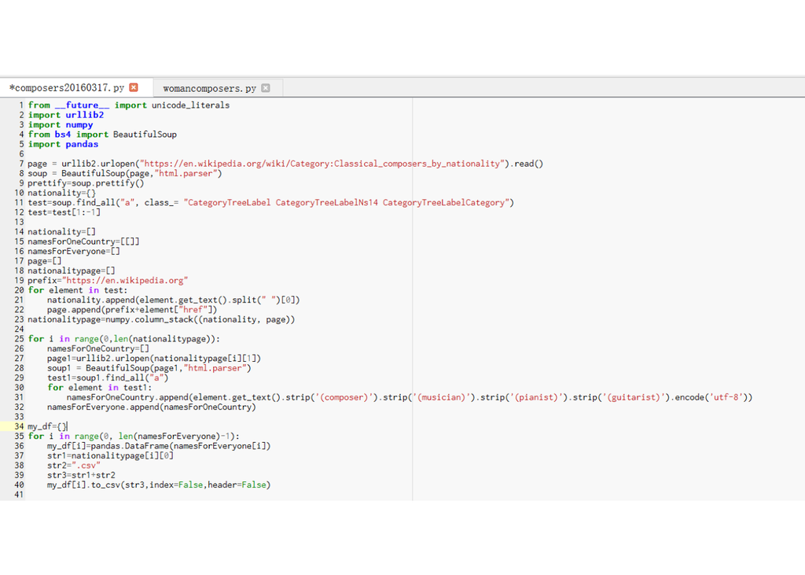

```r
img02 <- readPNG("2016-03-26b.png")
grid.raster(img02)
```

However, some pages, for example the American composer page (https://en.wikipedia.org/w/index.php?title=Category:American_classical_composers) has multiple pages, and it is hard to go through every page in my code. So I scraped every page by clicking by hand and rbind them together in R

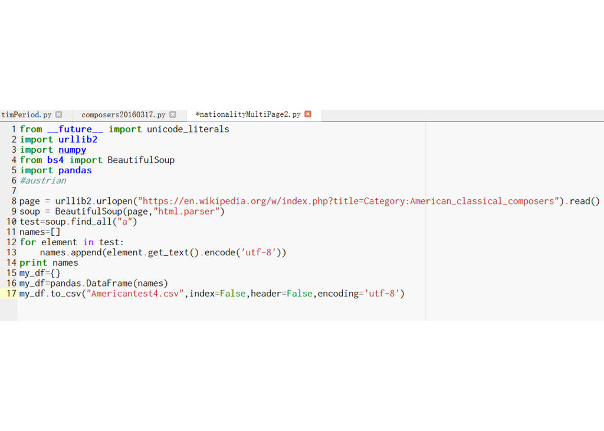

```r
img03 <- readPNG("scrapeNationality2.png")
grid.raster(img03)
```

#### American.

I stacked the data from multiple pages, cleaned them and matched them with the popularity score table and computed the proportion of the number of American composers whose works are performed by the NY Philharmonic over total number of works performed by the NY Philharmonic over time.

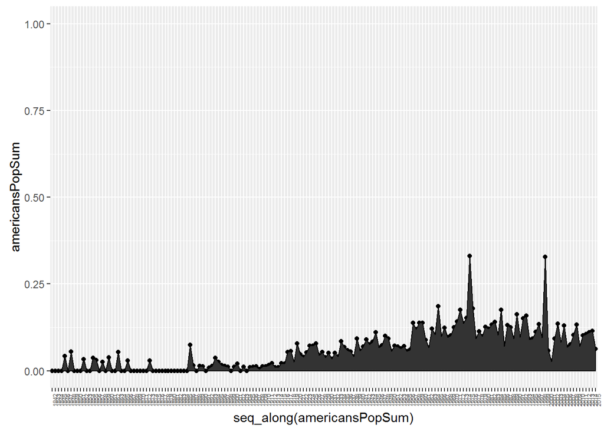

```r
require(ggplot2)
american1=read.csv("americantest1.csv", header = FALSE ,encoding = "UTF-8")
american2=read.csv("americantest2.csv", header = FALSE ,encoding = "UTF-8")
american3=read.csv("americantest3.csv", header = FALSE ,encoding = "UTF-8")
american4=read.csv("americantest4.csv", header = FALSE ,encoding = "UTF-8")
american5=read.csv("americantest5.csv", header = FALSE ,encoding = "UTF-8")
american6=read.csv("americantest6.csv", header = FALSE ,encoding = "UTF-8")
american7=read.csv("americantest7.csv", header = FALSE ,encoding = "UTF-8")
american=c(american1,american2,american3,american4,american5,american6,american7)
american=unique(unlist(american))

american1.0=gsub("\\(composer)|\\(pianist)|\\(conductor)|\\(guitarist)|\\(musician)|\\ (musicologist)|\\(singer-songwriter)|\\ (Fluxus musician)","",american)
american1.1=strsplit(as.character(american1.0)," ")

american1.2=list(rep(0,length(american1.1)))

for ( i in 1:length(american1.1)){
  if (length(american1.1[[i]])>1)
    american1.2[i]=paste(american1.1[[i]][length(american1.1[[i]])],paste(american1.1[[i]][1:length(american1.1[[i]])-1], collapse=" "),sep=", ")
}
american1.2=american1.2[!is.na(american1.2)]
l=list(rep(0, length(american1.2)))
l=c()
for ( i in 1:length(american1.2)){
  l=c(l,which(american1.2[i]==popScoreComposerComplete$composers))
}
americans=popScoreComposerComplete$composers[l]
americansPop=popScoreComposerComplete[l,]
americansPopSum=colSums(americansPop[2:175])
qplot(seq_along(americansPopSum),americansPopSum)+geom_line()+ylim(0,1)+geom_area(colour="black")+ scale_x_discrete(labels =(1842:2015))+ theme(axis.text.x = element_text(angle = 90,size=5, hjust = 1))
```

The graph shows a general increase of the proportion of the number of American composers over total number of composers over time, and the next step is to see the proportion of the number of American composers over the number of living composers over time.

The top twenty american composers are

```r
americanTop=rowSums(americansPop[2:175],na.rm=TRUE)
americanTop=cbind(as.data.frame(americans)[1],americanTop)
americanTop1=americanTop[order(-americanTop$americanTop),]
head(americanTop1,20)
```

```
##                      americans americanTop
## 507           Stravinsky, Igor  1.90049596
## 749             Copland, Aaron  1.39860893
## 943             Barber, Samuel  0.49238898
## 301         Sousa, John Philip  0.48272662
## 795              Ives, Charles  0.41547164
## 1061          Schuman, William  0.29622138
## 533         Schoenberg, Arnold  0.23453090
## 40   Bristow, George Frederick  0.22879103
## 215            Herbert, Victor  0.21835392
## 937                Weill, Kurt  0.20265775
## 336      Hadley, Henry Kimball  0.18554565
## 781                Harris, Roy  0.16361043
## 1029             Gould, Morton  0.14219377
## 595              Bloch, Ernest  0.12699405
## 1516         Schuller, Gunther  0.12658235
## 389          Schelling, Ernest  0.12004228
## 231           Damrosch, Walter  0.11967469
## 1896            Williams, John  0.11213021
## 1525           Carter, Elliott  0.10425231
## 1302           Anderson, Leroy  0.09459108
```

getting popularity scores for contemporary american composers

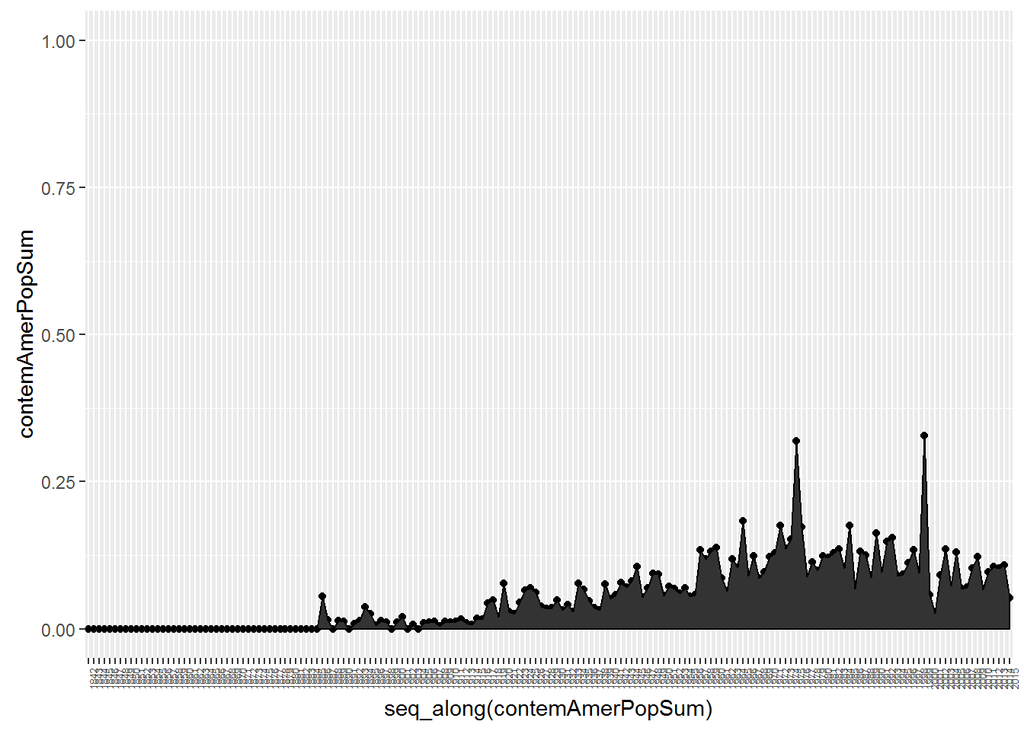

```r
l=c()
for ( i in 1:length(american1.2)){
  l=c(l,which(american1.2[i]==contem$composers))
}
contemAmer=contem$composers[l]
contemAmerPop=contem[l,]
contemAmerPopSum=colSums(contemAmerPop[2:175])
qplot(seq_along(contemAmerPopSum),contemAmerPopSum)+geom_line()+ylim(0,1)+geom_area(colour="black")+ scale_x_discrete(labels =(1842:2015))+ theme(axis.text.x = element_text(angle = 90,size=5, hjust = 1))
```

top twenty American contemporary composers

```r
contemAmerPop=rowSums(contemAmerPop[2:175],na.rm=TRUE)
contemAmerPopTop=cbind(as.data.frame(contemAmer)[1],contemAmerPop)
contemAmerPopTop1=contemAmerPopTop[order(-contemAmerPopTop$contemAmerPop),]
head(contemAmerPopTop1,20)
```

```
##                 contemAmer contemAmerPop
## 507       Stravinsky, Igor    1.90049596
## 749         Copland, Aaron    1.39860893
## 943         Barber, Samuel    0.49238898
## 301     Sousa, John Philip    0.48272662
## 795          Ives, Charles    0.41547164
## 1061      Schuman, William    0.29622138
## 533     Schoenberg, Arnold    0.23453090
## 215        Herbert, Victor    0.21835392
## 937            Weill, Kurt    0.20265775
## 336  Hadley, Henry Kimball    0.18554565
## 781            Harris, Roy    0.16361043
## 1029         Gould, Morton    0.14219377
## 595          Bloch, Ernest    0.12699405
## 1516     Schuller, Gunther    0.12658235
## 389      Schelling, Ernest    0.12004228
## 231       Damrosch, Walter    0.11967469
## 1896        Williams, John    0.11213021
## 1525       Carter, Elliott    0.10425231
## 1302       Anderson, Leroy    0.09459108
## 385        Kreisler, Fritz    0.09428862
```

#### Germany and austria

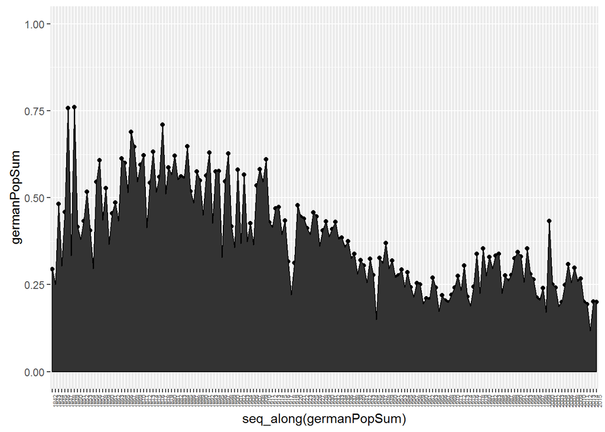

```r
german1=read.csv("germantest1.csv", header = FALSE ,encoding = "UTF-8")
german2=read.csv("germantest2.csv", header = FALSE ,encoding = "UTF-8")
german3=read.csv("germantest3.csv", header = FALSE ,encoding = "UTF-8")
german4=read.csv("germantest4.csv", header = FALSE ,encoding = "UTF-8")
german5=read.csv("germantest5.csv", header = FALSE ,encoding = "UTF-8")
austrian1=read.csv("austriantest1.csv", header = FALSE ,encoding = "UTF-8")
austrian2=read.csv("austriantest2.csv", header = FALSE ,encoding = "UTF-8")

german=c(german1,german2,german3,german4,german5)#,austrian1,austrian2)
german=unique(unlist(german))
german1.0=gsub("\\(composer)","",german)
german1.0=gsub("\\(baroque composer)","",german1.0)
german1.0=gsub("\\(Altstadt Kantor)","",german1.0)
german1.0=gsub("\\(Morean)","",german1.0)
german1.0=gsub("\\(1772–1806)","",german1.0)
german1.0=gsub("\\(conductor)","",german1.0)
german1.0=gsub("\\(the elder)","",german1.0)
german1.0=gsub("\\(the younger)","",german1.0)
german1.0=gsub("\\(musician)","",german1.0)
german1.0=gsub("\\(organist)","",german1.0)
german1.0=gsub("\\(guitarist)","",german1.0)
german1.0=gsub("\\(musician at Arnstadt)","",german1.0)
german1.0=gsub("\\(Austrian composer)","",german1.0)
german1.1=strsplit(as.character(german1.0)," ")

german1.2=list(rep(0,length(german1.1)))
for ( i in 1:length(german1.1)){
  if (length(german1.1[[i]])>1){
    german1.2[i]=paste(german1.1[[i]][length(german1.1[[i]])],paste(german1.1[[i]][1:length(german1.1[[i]])-1], collapse=" "),sep=", ")
  }
}
german1.2=german1.2[!is.na(german1.2)]

l=c()
for ( i in 1:length(german1.2)){
  l=c(l,which(german1.2[i]==popScoreComposerComplete$composers))
}
german=popScoreComposerComplete$composers[l]
germanPop=popScoreComposerComplete[l,]
germanPopSum=colSums(germanPop[2:175])
qplot(seq_along(germanPopSum),germanPopSum)+geom_line()+ylim(0,1)+geom_area(colour="black")+ scale_x_discrete(labels =(1842:2015))+ theme(axis.text.x = element_text(angle = 90,size=5, hjust = 1))
```

```r
germanTop=rowSums(germanPop[2:175],na.rm=TRUE)
germanTop=cbind(as.data.frame(german)[1],germanTop)
germanTop1=germanTop[order(-germanTop$germanTop),]
head(germanTop1,20)
```

```
##                         german  germanTop
## 1        Beethoven, Ludwig van 14.7532954
## 81             Wagner, Richard 11.6886530
## 5     Mozart, Wolfgang Amadeus  7.5860435
## 15          Mendelssohn, Felix  6.9929332
## 119           Brahms, Johannes  4.8857482
## 50            Schumann, Robert  4.1976142
## 122     Bach, Johann Sebastian  3.2870593
## 205           Strauss, Richard  2.8854791
## 74     Handel, George Frideric  2.0072171
## 16                Spohr, Louis  1.2947872
## 83  Gluck, Christoph Willibald  1.0359597
## 139                 Bruch, Max  0.6917327
## 145              Raff, Joachim  0.5810734
## 25          Meyerbeer, Giacomo  0.4829015
## 503         Offenbach, Jacques  0.3166258
## 769            Hindemith, Paul  0.2891123
## 159          Damrosch, Leopold  0.2597926
## 245     Humperdinck, Engelbert  0.2426095
## 134          Bargiel, Woldemar  0.2380020
## 937                Weill, Kurt  0.2026578
```

contemporary german and austrian composers’ popularity scores

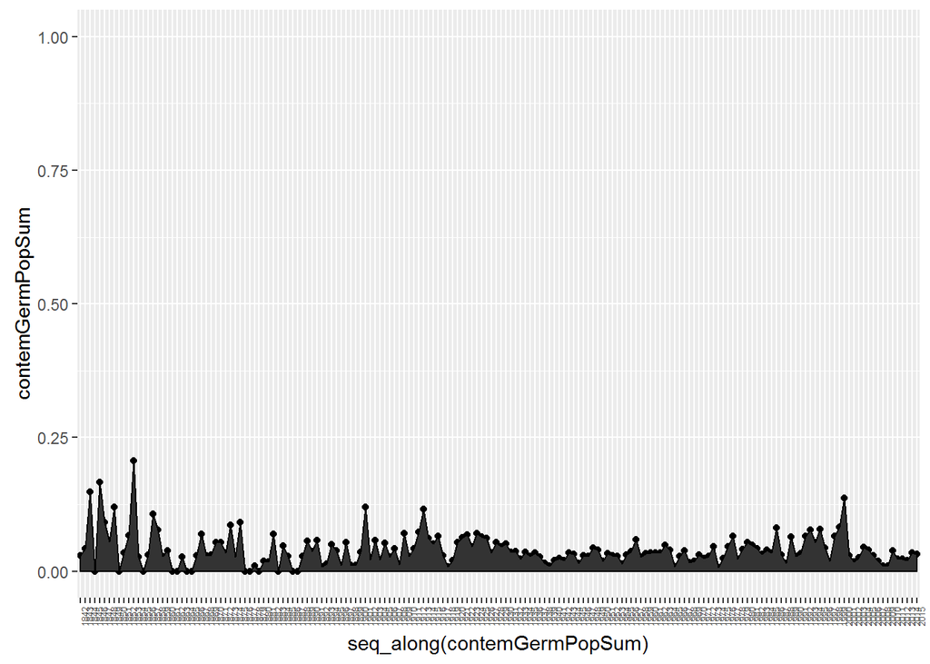

```r
l=c()
for ( i in 1:length(german1.2)){
  l=c(l,which(german1.2[i]==contem$composers))
}
contemGerm=contem$composers[l]
contemGermPop=contem[l,]
contemGermPopSum=colSums(contemGermPop[2:175])
qplot(seq_along(contemGermPopSum),contemGermPopSum)+geom_line()+ylim(0,1)+geom_area(colour="black")+ scale_x_discrete(labels =(1842:2015))+ theme(axis.text.x = element_text(angle = 90,size=5, hjust = 1))
```

```r
contemGermPop=rowSums(contemGermPop[2:175],na.rm=TRUE)
contemGermPopTop=cbind(as.data.frame(contemGerm)[1],contemGermPop)
contemGermPopTop1=contemGermPopTop[order(-contemGermPopTop$contemGermPop),]
head(contemGermPopTop1,20)
```

```
##                  contemGerm contemGermPop
## 205        Strauss, Richard    2.88547910
## 16             Spohr, Louis    1.29478717
## 139              Bruch, Max    0.69173275
## 25       Meyerbeer, Giacomo    0.48290150
## 769         Hindemith, Paul    0.28911230
## 245  Humperdinck, Engelbert    0.24260946
## 937             Weill, Kurt    0.20265775
## 223      Moszkowski, Moritz    0.15355482
## 444              Reger, Max    0.12018039
## 148          Reinecke, Carl    0.11752007
## 27       Kreutzer, Conradin    0.05979832
## 1210            Foss, Lukas    0.05023350
## 1688 Stockhausen, Karlheinz    0.04337462
## 207         Draeseke, Felix    0.02995752
## 1600             Orff, Carl    0.02337874
## 1625     Henze, Hans Werner    0.02240697
## 1901     Matthus, Siegfried    0.01542967
## 1416          Wolpe, Stefan    0.01528993
## 417          Pfitzner, Hans    0.01520081
## 1874       Schulhoff, Erwin    0.01497968
```

Contemporary German composers are never very popular in NY Phil probably because the deseased German composers are overshining over the contemporary composers.

##### Wagner

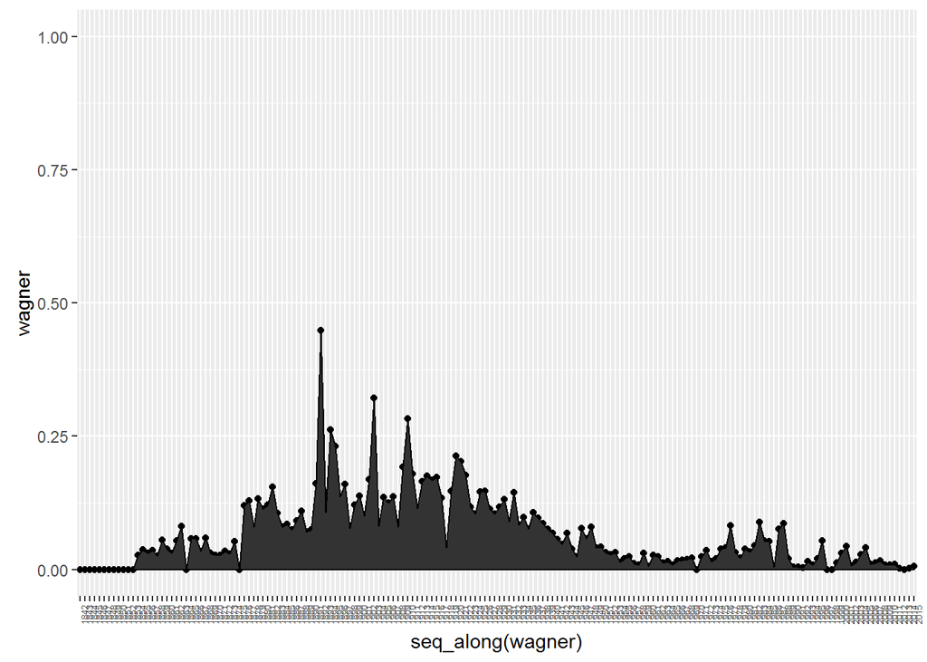

```r
wagner=as.numeric(popScoreComposerComplete[81,2:175])
qplot(seq_along(wagner),wagner)+geom_line()+geom_area(colour="black")+ylim(0,1)+ scale_x_discrete(labels =(1842:2015))+ theme(axis.text.x = element_text(angle = 90,size=5, hjust = 1))
```

The graph shows that Hitler’s favorite composer Wagner’s popularity significantly decreased after WWII.

#### “Soviet” countries

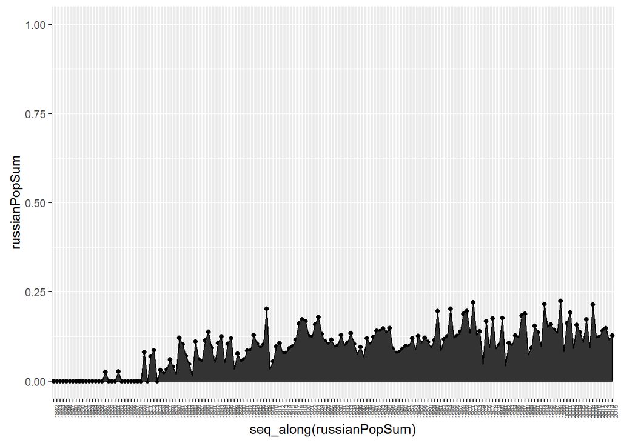

```r
russian1=read.csv("russiantest1.csv", header = FALSE ,encoding = "UTF-8")
russian2=read.csv("russiantest2.csv", header = FALSE ,encoding = "UTF-8")
czech1=read.csv("czechtest1.csv", header = FALSE ,encoding = "UTF-8")
czech2=read.csv("czechtest2.csv", header = FALSE ,encoding = "UTF-8")
hungarian=read.csv("Hungarian.csv", header = FALSE ,encoding = "UTF-8")
lithuanian=read.csv("Lithuanian.csv", header = FALSE ,encoding = "UTF-8")
romanian=read.csv("Romanian.csv", header = FALSE ,encoding = "UTF-8")
slovenian=read.csv("Slovenian.csv", header = FALSE ,encoding = "UTF-8")
ukrainian=read.csv("Ukrainian.csv", header = FALSE ,encoding = "UTF-8")
bulgarian=read.csv("Bulgarian.csv", header = FALSE ,encoding = "UTF-8")
polish=read.csv("Polish.csv", header = FALSE ,encoding = "UTF-8")
russian=c(russian1,russian2) #, czech1,czech2, hungarian,polish, lithuanian,romanian,slovenian,ukrainian,bulgarian)
russian=unique(unlist(russian))

russian1.0=gsub("\\(composer)","",russian)
russian1.0=gsub("\\(conductor)","",russian1.0)
russian1.1=strsplit(as.character(russian1.0)," ")

russian1.2=list(rep(0,length(russian1.1)))
for ( i in 1:length(russian1.1)){
  if (length(russian1.1[[i]])>1)
    russian1.2[i]=paste(russian1.1[[i]][length(russian1.1[[i]])],paste(russian1.1[[i]][1:length(russian1.1[[i]])-1], collapse=" "),sep=", ")
}
russian1.2=russian1.2[!is.na(russian1.2)]
l=c()
for ( i in 1:length(russian1.2)){
  l=c(l,which(russian1.2[i]==popScoreComposerComplete$composers))
}

russian=popScoreComposerComplete$composers[l]
russianPop=popScoreComposerComplete[l,]
russianPopSum=colSums(russianPop[2:175])
qplot(seq_along(russianPopSum),russianPopSum)+geom_line()+ylim(0,1)+geom_area(colour="black")+ scale_x_discrete(labels =(1842:2015))+ theme(axis.text.x = element_text(angle = 90,size=5, hjust = 1))
```

```r
russianTop=rowSums(russianPop[2:175],na.rm=TRUE)
russianTop=cbind(as.data.frame(russian)[1],russianTop)
russianTop1=russianTop[order(-russianTop$russianTop),]
#test1=rowSums(popScoreSumComp1$popScoreSumComp)
head(russianTop1,20)
```

```
##                        russian  russianTop
## 163  Tchaikovsky, Pyotr Ilyich 6.991801573
## 674          Prokofiev, Sergei 1.965981348
## 507           Stravinsky, Igor 1.900495957
## 97           Rubinstein, Anton 1.362660529
## 293   Rimsky-Korsakov, Nikolai 1.152653401
## 402       Rachmaninoff, Sergei 0.995930052
## 880       Shostakovich, Dmitri 0.797192672
## 171            Glinka, Mikhail 0.288726201
## 268         Borodin, Alexander 0.286503371
## 274        Glazunov, Alexander 0.218938826
## 613  Ippolitov-Ivanov, Mikhail 0.132735239
## 384        Scriabin, Alexander 0.108151986
## 1872        Gubaidulina, Sofia 0.054018666
## 1880         Schnittke, Alfred 0.051375466
## 1657         Shchedrin, Rodion 0.014854310
## 310        Tcherepnin, Nikolai 0.010836833
## 909         Mosolov, Alexander 0.008512919
## 1198              Knipper, Lev 0.006883727
## 2628          Medtner, Nikolai 0.006250000
## 1804           Taneyev, Sergei 0.004613806
```

contemporary russian composers’ popularity scores

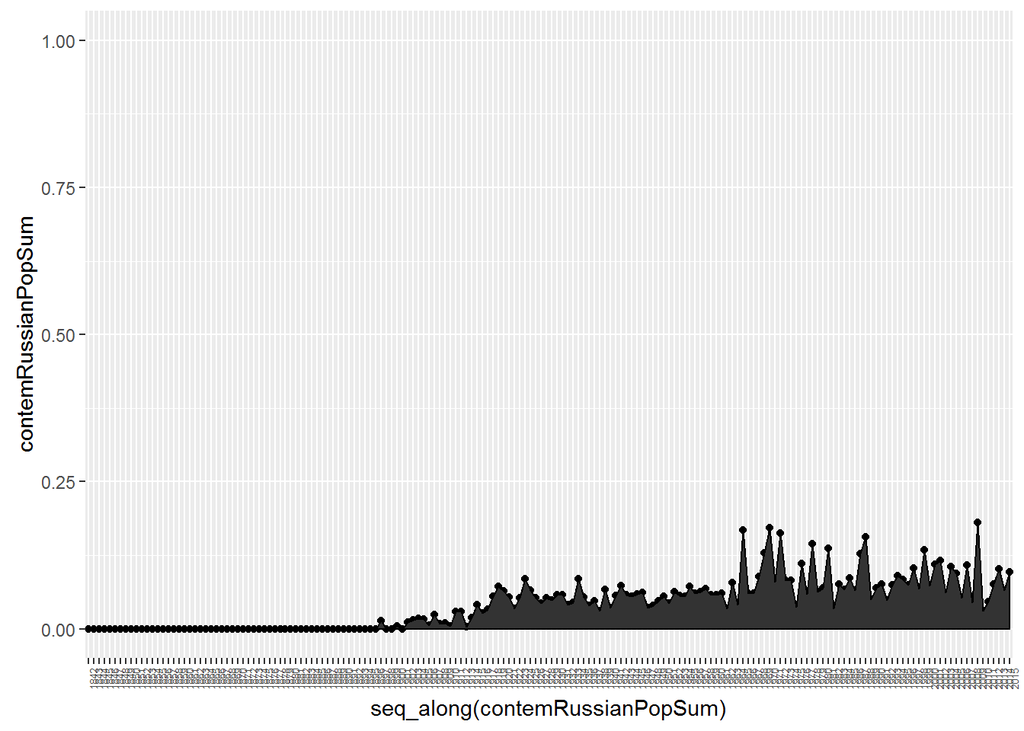

```r
l=c()
for ( i in 1:length(russian1.2)){
  l=c(l,which(russian1.2[i]==contem$composers))
}
contemRussian=contem$composers[l]
contemRussianPop=contem[l,]
contemRussianPopSum=colSums(contemRussianPop[2:175])
qplot(seq_along(contemRussianPopSum),contemRussianPopSum)+geom_line()+ylim(0,1)+geom_area(colour="black")+ scale_x_discrete(labels =(1842:2015))+ theme(axis.text.x = element_text(angle = 90,size=5, hjust = 1))
```

```r
contemRussianPop=rowSums(contemRussianPop[2:175],na.rm=TRUE)
contemRussianPopTop=cbind(as.data.frame(contemRussian)[1],contemRussianPop)
contemRussianPopTop1=contemRussianPopTop[order(-contemRussianPopTop$contemRussianPop),]
#test1=rowSums(popScoreSumComp1$popScoreSumComp)
head(contemRussianPopTop1,20)
```

```
##                  contemRussian contemRussianPop
## 674          Prokofiev, Sergei      1.965981348
## 507           Stravinsky, Igor      1.900495957
## 293   Rimsky-Korsakov, Nikolai      1.152653401
## 402       Rachmaninoff, Sergei      0.995930052
## 880       Shostakovich, Dmitri      0.797192672
## 274        Glazunov, Alexander      0.218938826
## 613  Ippolitov-Ivanov, Mikhail      0.132735239
## 384        Scriabin, Alexander      0.108151986
## 1872        Gubaidulina, Sofia      0.054018666
## 1880         Schnittke, Alfred      0.051375466
## 1657         Shchedrin, Rodion      0.014854310
## 310        Tcherepnin, Nikolai      0.010836833
## 909         Mosolov, Alexander      0.008512919
## 1198              Knipper, Lev      0.006883727
## 2628          Medtner, Nikolai      0.006250000
## 1804           Taneyev, Sergei      0.004613806
## 753      Tcherepnin, Alexander      0.004228038
## 1929         Slonimsky, Sergei      0.002906977
## 1419        Slonimsky, Nicolas      0.002866074
## 1658           Denisov, Edison      0.002739726
```

The graph shows that there is an increase of Russian composers after WWII during the cold war, probably because many important Russian composers rise during that time. This shows that the cold war does not affect the introducing of Russian music to the US.

##### shostakovich

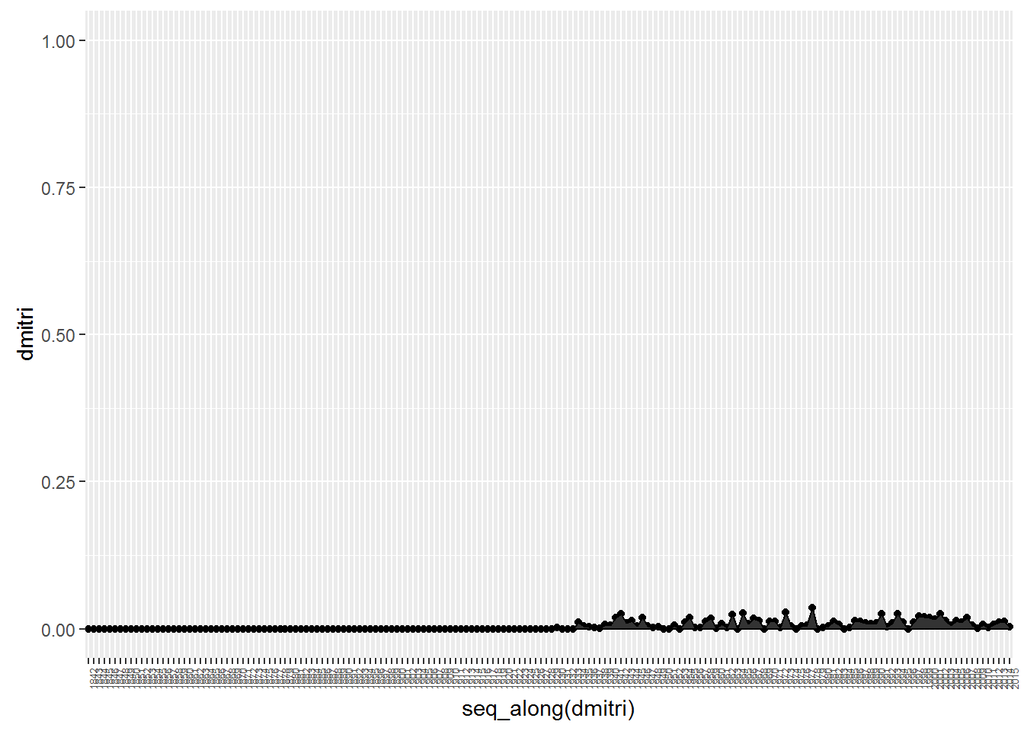

```r
test=grep("Shostakovich",popScoreComposerComplete$composers)
dmitri=as.numeric(popScoreComposerComplete[test,2:175])
qplot(seq_along(dmitri),dmitri)+geom_line()+ylim(0,1)+geom_area(colour="black")+ scale_x_discrete(labels =(1842:2015))+ theme(axis.text.x = element_text(angle = 90,size=5, hjust = 1))
```

#### french

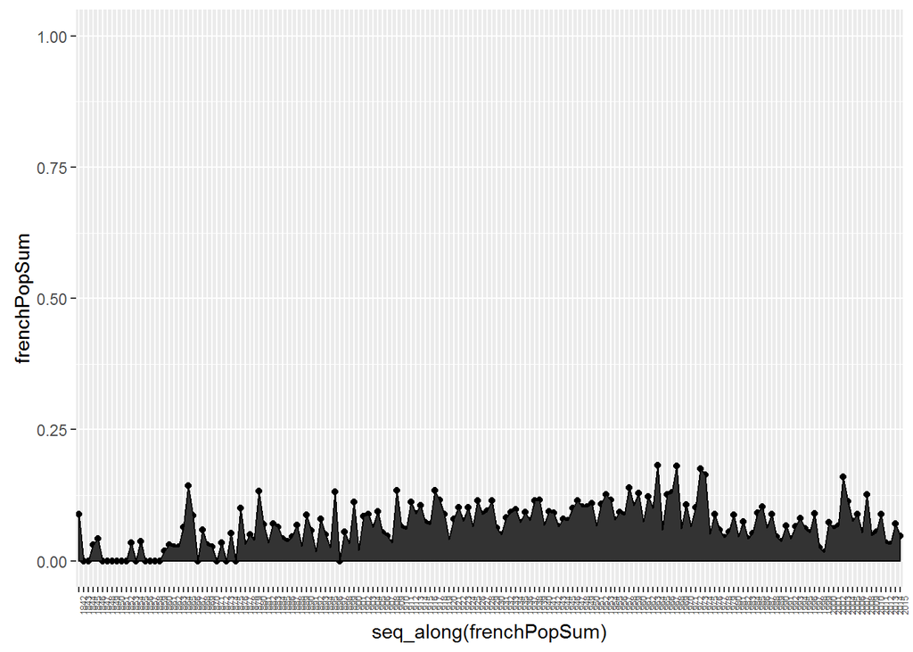

```r
french1=read.csv("frenchtest1.csv", header = FALSE ,encoding = "UTF-8")
french2=read.csv("frenchtest2.csv", header = FALSE ,encoding = "UTF-8")
french3=read.csv("frenchtest3.csv", header = FALSE ,encoding = "UTF-8")
french4=read.csv("frenchtest4.csv", header = FALSE ,encoding = "UTF-8")
french=c(french1,french2,french3,french4)
french=unique(unlist(french))

french1.0=gsub("\\(composer)","",french)
french1.0=gsub("\\(conductor)","",french1.0)
french1.0=gsub("\\(1907–1970)","",french1.0)
french1.0=gsub("\\(organist)","",french1.0)
french1.0=gsub("\\(violist)","",french1.0)
french1.0=gsub("\\(musician) ","",french1.0)
french1.0=gsub("\\(Chantilly Codex composer) ","",french1.0)
french1.0=gsub("\\(lutenist)  ","",french1.0)
french1.1=strsplit(as.character(french1.0)," ")

french1.2=list(rep(0,length(french1.1)))
for ( i in 1:length(french1.1)){
  if (length(french1.1[[i]])>1)
    french1.2[i]=paste(french1.1[[i]][length(french1.1[[i]])],paste(french1.1[[i]][1:length(french1.1[[i]])-1], collapse=" "),sep=", ")
}
french1.2=french1.2[!is.na(french1.2)]
l=c()
for ( i in 1:length(french1.2)){
  l=c(l,which(french1.2[i]==popScoreComposerComplete$composers))
}

french=popScoreComposerComplete$composers[l]
frenchPop=popScoreComposerComplete[l,]
frenchPopSum=colSums(frenchPop[2:175])
qplot(seq_along(frenchPopSum),frenchPopSum)+geom_line()+ylim(0,1)+geom_area(colour="black")+ scale_x_discrete(labels =(1842:2015))+ theme(axis.text.x = element_text(angle = 90,size=5, hjust = 1))
```

```r
frenchTop=rowSums(frenchPop[2:175],na.rm=TRUE)
frenchTop=cbind(as.data.frame(french)[1],frenchTop)
frenchTop1=frenchTop[order(-frenchTop$frenchTop),]
#test1=rowSums(popScoreSumComp1$popScoreSumComp)
head(frenchTop1,20)
```

```
##                     french  frenchTop
## 37         Berlioz, Hector 3.88238857
## 400         Ravel, Maurice 1.85075377
## 359        Debussy, Claude 1.74291685
## 187         Bizet, Georges 0.97999200
## 204        Massenet, Jules 0.37918047
## 125        Gounod, Charles 0.37308761
## 503     Offenbach, Jacques 0.31662581
## 401            Dukas, Paul 0.30650214
## 298     Chabrier, Emmanuel 0.24573813
## 197       Thomas, Ambroise 0.17276699
## 164  Rameau, Jean-Philippe 0.15965696
## 361       Chausson, Ernest 0.12786807
## 279   Charpentier, Gustave 0.12354508
## 743       Honegger, Arthur 0.12243434
## 768       Poulenc, Francis 0.11586613
## 792        Milhaud, Darius 0.10732493
## 506        Roussel, Albert 0.09466475
## 790         Ibert, Jacques 0.08922502
## 1349     Messiaen, Olivier 0.07934661
## 236       Godard, Benjamin 0.06510235
```

contemporary french composers’ popularity scores

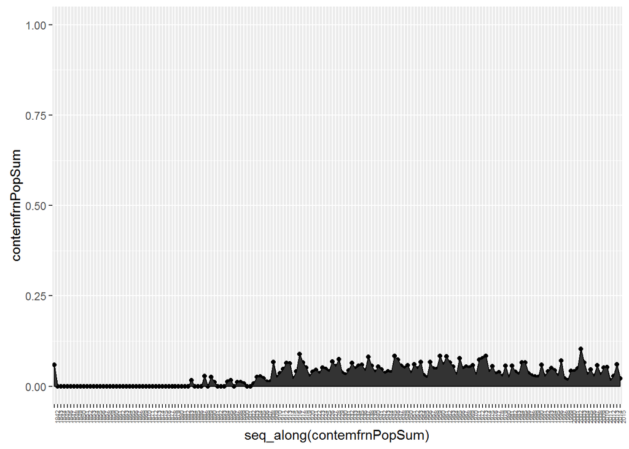

```r
l=c()
for ( i in 1:length(french1.2)){
  l=c(l,which(french1.2[i]==contem$composers))
}
contemfrn=contem$composers[l]
contemfrnPop=contem[l,]
contemfrnPopSum=colSums(contemfrnPop[2:175])
qplot(seq_along(contemfrnPopSum),contemfrnPopSum)+geom_line()+ylim(0,1)+geom_area(colour="black")+ scale_x_discrete(labels =(1842:2015))+ theme(axis.text.x = element_text(angle = 90,size=5, hjust = 1))
```

```r
contemfrnPop=rowSums(contemfrnPop[2:175],na.rm=TRUE)
contemfrnPopTop=cbind(as.data.frame(contemfrn)[1],contemfrnPop)
contemfrnPopTop1=contemfrnPopTop[order(-contemfrnPopTop$contemfrnPop),]
head(contemfrnPopTop1,20)
```

```
##                 contemfrn contemfrnPop
## 400        Ravel, Maurice   1.85075377
## 359       Debussy, Claude   1.74291685
## 204       Massenet, Jules   0.37918047
## 401           Dukas, Paul   0.30650214
## 279  Charpentier, Gustave   0.12354508
## 743      Honegger, Arthur   0.12243434
## 768      Poulenc, Francis   0.11586613
## 792       Milhaud, Darius   0.10732493
## 506       Roussel, Albert   0.09466475
## 790        Ibert, Jacques   0.08922502
## 1349    Messiaen, Olivier   0.07934661
## 353         Duparc, Henri   0.06491937
## 10         Onslow, George   0.05882353
## 1591       Boulez, Pierre   0.05052477
## 850           Satie, Erik   0.04380251
## 1543     Dutilleux, Henri   0.03878893
## 1314   Canteloube, Joseph   0.03735099
## 1632      Xenakis, Iannis   0.02700159
## 767    Tansman, Alexandre   0.02317065
## 575         Rabaud, Henri   0.02107178
```

#### italian

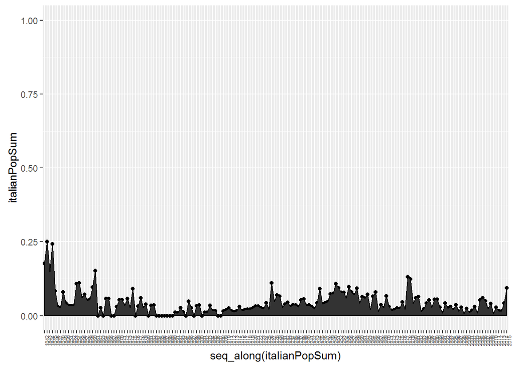

```r
itallian1=read.csv("italiantest1.csv", header = FALSE ,encoding = "UTF-8")
itallian2=read.csv("italiantest2.csv", header = FALSE ,encoding = "UTF-8")
itallian3=read.csv("italiantest3.csv", header = FALSE ,encoding = "UTF-8")
itallian4=read.csv("italiantest4.csv", header = FALSE ,encoding = "UTF-8")
itallian5=read.csv("italiantest5.csv", header = FALSE ,encoding = "UTF-8")
italian=c(itallian1,itallian2,itallian3,itallian4,itallian5)
italian=unique(unlist(italian))

italian1.0=gsub("\\(composer)","",italian)
italian1.0=gsub("\\(conductor)","",italian1.0)
italian1.0=gsub("\\(classical era composer)","",italian1.0)
italian1.0=gsub("\\ (senior)","",italian1.0)
italian1.1=strsplit(as.character(italian1.0)," ")

italian1.2=list(rep(0,length(italian1.1)))
for ( i in 1:length(italian1.1)){
  if (length(italian1.1[[i]])>1)
    italian1.2[i]=paste(italian1.1[[i]][length(italian1.1[[i]])],paste(italian1.1[[i]][1:length(italian1.1[[i]])-1], collapse=" "),sep=", ")
}
italian1.2=italian1.2[!is.na(italian1.2)]
l=c()
for ( i in 1:length(italian1.2)){
  l=c(l,which(italian1.2[i]==popScoreComposerComplete$composers))
}

italian=popScoreComposerComplete$composers[l]
italianPop=popScoreComposerComplete[l,]
italianPopSum=colSums(italianPop[2:175])
qplot(seq_along(italianPopSum),italianPopSum)+geom_line()+ylim(0,1)+geom_area(colour="black")+ scale_x_discrete(labels =(1842:2015))+ theme(axis.text.x = element_text(angle = 90,size=5, hjust = 1))
```

```r
italianTop=rowSums(italianPop[2:175],na.rm=TRUE)
italianTop=cbind(as.data.frame(italian)[1],italianTop)
italianTop1=italianTop[order(-italianTop$italianTop),]
#test1=rowSums(popScoreSumComp1$popScoreSumComp)
head(italianTop1,20)
```

```
##                    italian italianTop
## 4       Rossini, Gioachino 1.47566775
## 38         Verdi, Giuseppe 1.19659419
## 18      Donizetti, Gaetano 0.79645028
## 28        Cherubini, Luigi 0.52236674
## 324       Puccini, Giacomo 0.45827854
## 7        Bellini, Vincenzo 0.39002577
## 623     Respighi, Ottorino 0.36888394
## 447       Vivaldi, Antonio 0.31968527
## 9         Pacini, Giovanni 0.12573211
## 175      Boccherini, Luigi 0.11569680
## 987     Gabrieli, Giovanni 0.10727565
## 1123   Menotti, Gian Carlo 0.09173476
## 1673        Berio, Luciano 0.08432223
## 260   Leoncavallo, Ruggero 0.08249445
## 448  Wolf-Ferrari, Ermanno 0.07725418
## 621       Casella, Alfredo 0.05634322
## 413      Busoni, Ferruccio 0.05435054
## 558   Ponchielli, Amilcare 0.05359123
## 311       Mascagni, Pietro 0.05318986
## 662     Corelli, Arcangelo 0.05227997
```

contemporary italian composers’ popularity scores

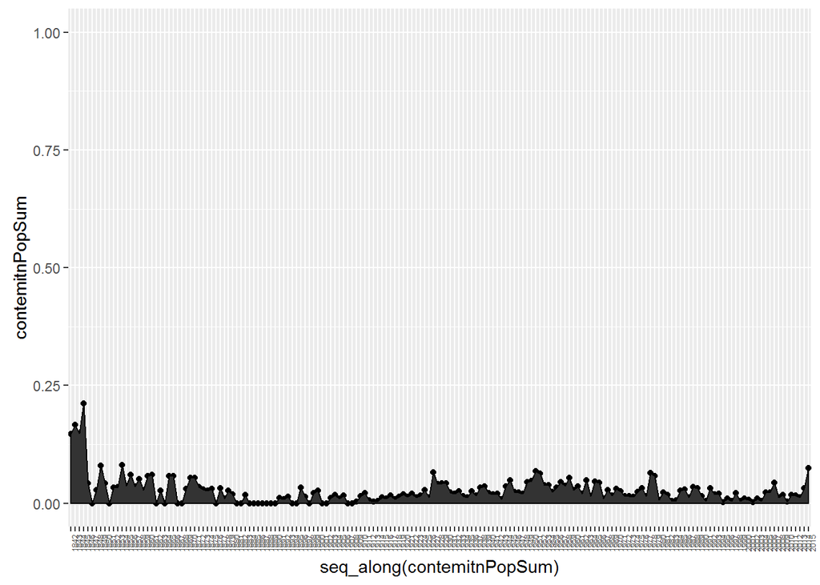

```r
l=c()
for ( i in 1:length(italian1.2)){
  l=c(l,which(italian1.2[i]==contem$composers))
}
contemitn=contem$composers[l]
contemitnPop=contem[l,]
contemitnPopSum=colSums(contemitnPop[2:175])
qplot(seq_along(contemitnPopSum),contemitnPopSum)+geom_line()+ylim(0,1)+geom_area(colour="black")+ scale_x_discrete(labels =(1842:2015))+ theme(axis.text.x = element_text(angle = 90,size=5, hjust = 1))
```

```r
contemitnPop=rowSums(contemitnPop[2:175],na.rm=TRUE)
contemitnPopTop=cbind(as.data.frame(contemitn)[1],contemitnPop)
contemitnPopTop1=contemitnPopTop[order(-contemitnPopTop$contemitnPop),]
head(contemitnPopTop1,20)
```

```
##                      contemitn contemitnPop
## 4           Rossini, Gioachino   1.47566775
## 18          Donizetti, Gaetano   0.79645028
## 28            Cherubini, Luigi   0.52236674
## 324           Puccini, Giacomo   0.45827854
## 623         Respighi, Ottorino   0.36888394
## 9             Pacini, Giovanni   0.12573211
## 1123       Menotti, Gian Carlo   0.09173476
## 1673            Berio, Luciano   0.08432223
## 260       Leoncavallo, Ruggero   0.08249445
## 448      Wolf-Ferrari, Ermanno   0.07725418
## 621           Casella, Alfredo   0.05634322
## 413          Busoni, Ferruccio   0.05435054
## 311           Mascagni, Pietro   0.05318986
## 1389          Cilea, Francesco   0.04121359
## 427          Sinigaglia, Leone   0.03210877
## 367          Giordano, Umberto   0.02977393
## 1451       Dallapiccola, Luigi   0.02668698
## 1545                Rota, Nino   0.02477254
## 765            Rieti, Vittorio   0.01718249
## 650  Malipiero, Gian Francesco   0.01664635
```

#### asian and latin american

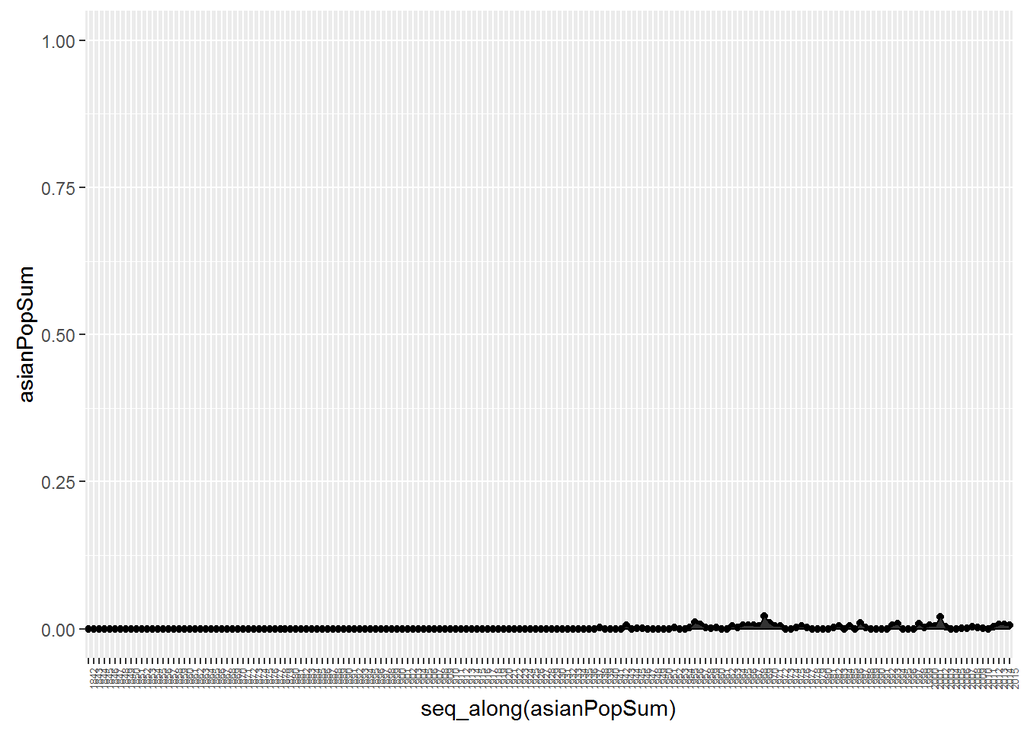

```r
chinese=read.csv("Chinese.csv", header = FALSE ,encoding = "UTF-8")
taiwanese=read.csv("Taiwanese.csv", header = FALSE ,encoding = "UTF-8")
japanese=read.csv("Japanese.csv", header = FALSE ,encoding = "UTF-8")
indian=read.csv("Indian.csv", header = FALSE ,encoding = "UTF-8")
turkish=read.csv("Turkish.csv", header = FALSE ,encoding = "UTF-8")
iranian=read.csv("Iranian.csv", header = FALSE ,encoding = "UTF-8")

mexican=read.csv("Mexican.csv", header = FALSE ,encoding = "UTF-8")
brazilian=read.csv("Brazilian.csv", header = FALSE ,encoding = "UTF-8")
argentine=read.csv("Argentine.csv", header = FALSE ,encoding = "UTF-8")
asian=c(chinese, taiwanese,japanese, indian,turkish, brazilian, argentine)
asian=unique(unlist(asian))

asian1.0=gsub("\\(composer)","",asian)
asian1.0=gsub("\\(musician)","",asian1.0)
asian1.1=strsplit(as.character(asian1.0)," ")

asian1.2=list(rep(0,length(asian1.1)))
for ( i in 1:length(asian1.1)){
  if (length(asian1.1[[i]])>1)
    asian1.2[i]=paste(asian1.1[[i]][length(asian1.1[[i]])],paste(asian1.1[[i]][1:length(asian1.1[[i]])-1], collapse=" "),sep=", ")
}
asian1.2=asian1.2[!is.na(asian1.2)]
l=c()
for ( i in 1:length(asian1.2)){
  l=c(l,which(asian1.2[i]==popScoreComposerComplete$composers))
}

asian=popScoreComposerComplete$composers[l]
asianPop=popScoreComposerComplete[l,]
asianPopSum=colSums(asianPop[2:175])
qplot(seq_along(asianPopSum),asianPopSum)+geom_line()+ylim(0,1)+geom_area(colour="black")+ scale_x_discrete(labels =(1842:2015))+ theme(axis.text.x = element_text(angle = 90,size=5, hjust = 1))
```

```r
asianTop=rowSums(asianPop[2:175],na.rm=TRUE)
asianTop=cbind(as.data.frame(asian)[1],asianTop)
asianTop1=asianTop[order(-asianTop$asianTop),]
#test1=rowSums(popScoreSumComp1$popScoreSumComp)
head(asianTop1,20)
```

```
##                   asian    asianTop
## 1521 Ginastera, Alberto 0.083441935
## 1644    Takemitsu, Toru 0.033460635
## 2060           Dun, Tan 0.031725904
## 1188 Guarnieri, Camargo 0.017799450
## 2138   Golijov, Osvaldo 0.012001243
## 1692  Davidovsky, Mario 0.009990710
## 1487     Miyagi, Michio 0.006000250
## 1611  Mayuzumi, Toshiro 0.005707111
## 1970       Miki, Minoru 0.005602241
## 1488   Konoye, Hidemaro 0.005045251
## 2081       Satoh, Somei 0.004745125
## 1051 Mignone, Francisco 0.004455386
## 2532      Fujikura, Dai 0.002899480
## 1891    Kagel, Mauricio 0.002610966
## 1855        Yuasa, Joji 0.002604167
## 1641  Koyama, Kiyoshige 0.002049180
## 2531   Hosokawa, Toshio 0.001377410
## 2230     Schifrin, Lalo 0.001322751
## 2326         Liang, Lei 0.001138952
```

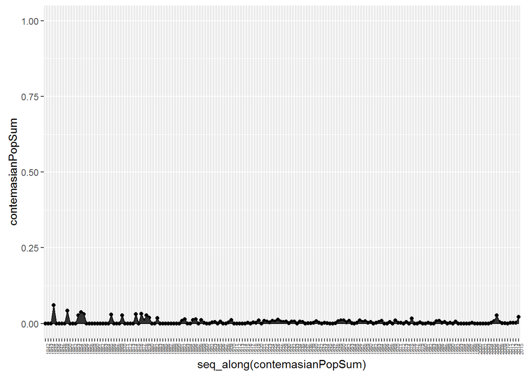

```r
l=c()
for ( i in 1:length(asian1.2)){
  l=c(l,which(italian1.2[i]==contem$composers))
}
contemasian=contem$composers[l]
contemasianPop=contem[l,]
contemasianPopSum=colSums(contemasianPop[2:175])
qplot(seq_along(contemasianPopSum),contemasianPopSum)+geom_line()+ylim(0,1)+geom_area(colour="black")+ scale_x_discrete(labels =(1842:2015))+ theme(axis.text.x = element_text(angle = 90,size=5, hjust = 1))
```

```r
contemasianPop=rowSums(contemasianPop[2:175],na.rm=TRUE)
contemasianPopTop=cbind(as.data.frame(contemasian)[1],contemasianPop)
contemasianPopTop1=contemasianPopTop[order(-contemasianPopTop$contemasianPop),]
head(contemasianPopTop1,20)
```

```
##              contemasian contemasianPop
## 28      Cherubini, Luigi    0.522366738
## 1673      Berio, Luciano    0.084322228
## 621     Casella, Alfredo    0.056343220
## 413    Busoni, Ferruccio    0.054350536
## 1389    Cilea, Francesco    0.041213586
## 1451 Dallapiccola, Luigi    0.026686980
## 262        Arditi, Luigi    0.013920739
## 643        Boito, Arrigo    0.012189868
## 429  Bossi, Marco Enrico    0.011774473
## 1882   Bussotti, Sylvano    0.002610966
## 2310        Corghi, Azio    0.001138952
```

#### jewish composers

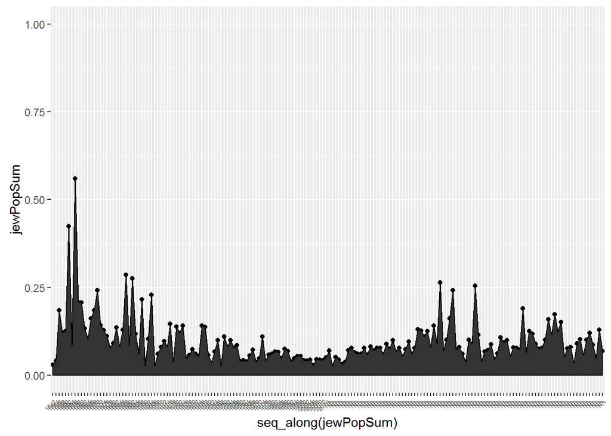

```r
jew1=read.csv("jew1.csv", header = FALSE ,encoding = "UTF-8")
jew2=read.csv("jew2.csv", header = FALSE ,encoding = "UTF-8")

jew=c(jew1,jew2)
jew=unique(unlist(jew))

jew1.0=gsub("\\(composer)","",jew)
jew1.0=gsub("\\(Dutch composer)","",jew1.0)
jew1.0=gsub("\\musician","",jew1.0)
jew1.1=strsplit(as.character(jew1.0)," ")

jew1.2=list(rep(0,length(jew1.1)))
for ( i in 1:length(jew1.1)){
  if (length(jew1.1[[i]])>1)
    jew1.2[i]=paste(jew1.1[[i]][length(jew1.1[[i]])],paste(jew1.1[[i]][1:length(jew1.1[[i]])-1], collapse=" "),sep=", ")
}
jew1.2=jew1.2[!is.na(jew1.2)]
l=c()
for ( i in 1:length(jew1.2)){
  l=c(l,which(jew1.2[i]==popScoreComposerComplete$composers))
}

jew=popScoreComposerComplete$composers[l]
jewPop=popScoreComposerComplete[l,]
jewPopSum=colSums(jewPop[2:175])
qplot(seq_along(jewPopSum),jewPopSum)+geom_line()+ylim(0,1)+geom_area(colour="black")+  theme(axis.text.x = element_text(angle = 45,size=5, hjust = 1))+scale_x_discrete(labels=seq(1842,2015,by=2))
```

```r
jewTop=rowSums(jewPop[2:175],na.rm=TRUE)
jewTop=cbind(as.data.frame(jew)[1],jewTop)
jewTop1=jewTop[order(-jewTop$jewTop),]
#test1=rowSums(popScoreSumComp1$popScoreSumComp)
head(jewTop1,20)
```

```
##                           jew     jewTop
## 15         Mendelssohn, Felix 6.99293323
## 770          Gershwin, George 1.92825688
## 97          Rubinstein, Anton 1.36266053
## 354            Mahler, Gustav 1.24741530
## 1193       Bernstein, Leonard 1.19880250
## 146            Goldmark, Karl 0.65090673
## 25         Meyerbeer, Giacomo 0.48290150
## 503        Offenbach, Jacques 0.31662581
## 401               Dukas, Paul 0.30650214
## 1061         Schuman, William 0.29622138
## 533        Schoenberg, Arnold 0.23453090
## 937               Weill, Kurt 0.20265775
## 41          Hiller, Ferdinand 0.19690678
## 223        Moszkowski, Moritz 0.15355482
## 595             Bloch, Ernest 0.12699405
## 792           Milhaud, Darius 0.10732493
## 385           Kreisler, Fritz 0.09428862
## 88   Gottschalk, Louis Moreau 0.08277290
## 44           Moscheles, Ignaz 0.08240315
## 236          Godard, Benjamin 0.06510235
```

contemporary jewish composers’ popularity scores

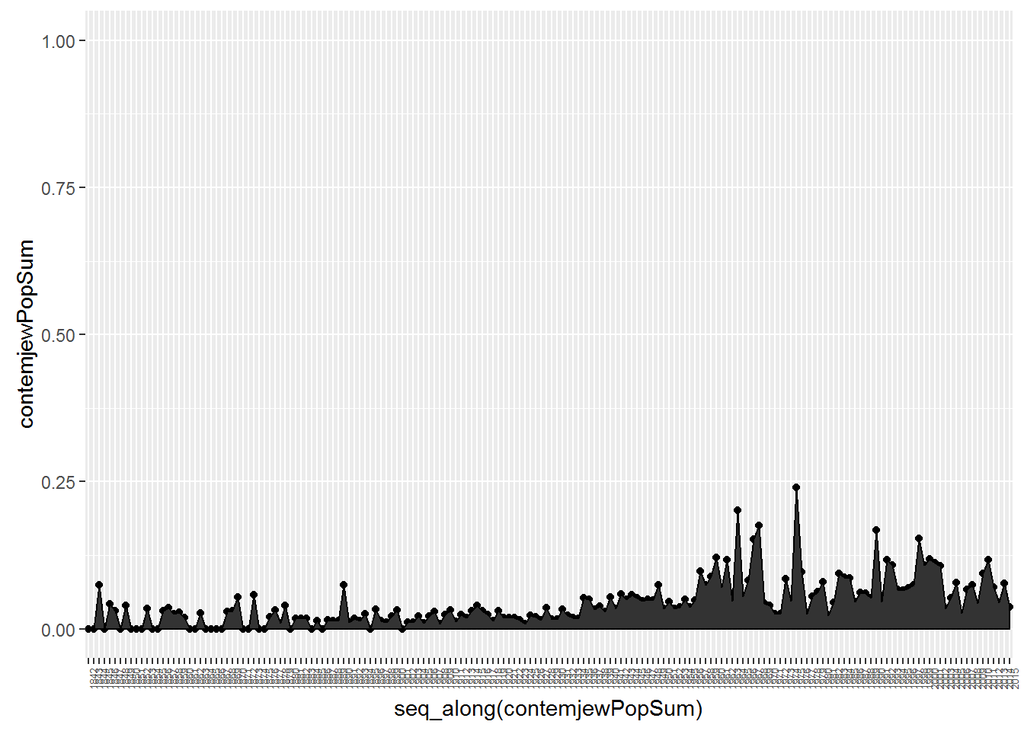

```r
l=c()
for ( i in 1:length(jew1.2)){
  l=c(l,which(jew1.2[i]==contem$composers))
}
contemjew=contem$composers[l]
contemjewPop=contem[l,]
contemjewPopSum=colSums(contemjewPop[2:175])
qplot(seq_along(contemjewPopSum),contemjewPopSum)+geom_line()+ylim(0,1)+geom_area(colour="black")+ scale_x_discrete(labels =(1842:2015))+ theme(axis.text.x = element_text(angle = 90,size=5, hjust = 1))
```

```r
contemjewPop=rowSums(contemjewPop[2:175],na.rm=TRUE)
contemjewPopTop=cbind(as.data.frame(contemjew)[1],contemjewPop)
contemjewPopTop1=contemjewPopTop[order(-contemjewPopTop$contemjewPop),]
head(contemjewPopTop1,20)
```

```
##               contemjew contemjewPop
## 770    Gershwin, George   1.92825688
## 354      Mahler, Gustav   1.24741530
## 1193 Bernstein, Leonard   1.19880250
## 146      Goldmark, Karl   0.65090673
## 25   Meyerbeer, Giacomo   0.48290150
## 401         Dukas, Paul   0.30650214
## 1061   Schuman, William   0.29622138
## 533  Schoenberg, Arnold   0.23453090
## 937         Weill, Kurt   0.20265775
## 223  Moszkowski, Moritz   0.15355482
## 595       Bloch, Ernest   0.12699405
## 792     Milhaud, Darius   0.10732493
## 385     Kreisler, Fritz   0.09428862
## 44     Moscheles, Ignaz   0.08240315
## 1880  Schnittke, Alfred   0.05137547
## 1034     Diamond, David   0.03684572
## 427   Sinigaglia, Leone   0.03210877
## 225     Joachim, Joseph   0.02606045
## 767  Tansman, Alexandre   0.02317065
## 1837  Kernis, Aaron Jay   0.02218499
```

```r
total=matrix(c( "american",americansPopSum,
                "german",germanPopSum,
                "french",frenchPopSum,
                "italian",italianPopSum,
                "soviet",russianPopSum,
                "asian and latin",asianPopSum),
               nrow=6,byrow=T)
total=as.data.frame(total)
test=unlist(strsplit(paste(1:175,"V",collapse="")," "))
test=test[-1]
test=test[-175]
total=reshape(total,
              varying=test,
              v.names="scores",
              timevar="seasons",
              times=test,
              direction = "long")
total=select(V)
total=na.omit(total)
#ggplot(total, aes(x=seasons,y=scores,color=V1,group=V1))+geom_area()
#qplot(total,aes(x=seasons,y=scores,color=V1,group=V1))+geom_area()
```

https://www.safaribooksonline.com/library/view/r-graphics-cookbook/9781449363086/ch04.html

#### The Rise of Women Composers

The feminist movements accelerated in 1960s. It first starts in political and economics equality between men and women, and spread to the culture sectors. Can we find this reflected in NY Phil performance data?

We need the proportion of the number of woman composers over the total number of composers whose works are performed by the NY philharmonic over time, but NY Philharmonic’s data do not have gender information for each composer. Therefore, I scraped wikipedia pages’ listing women composers (https://en.wikipedia.org/wiki/List_of_female_composers_by_birth_year) in python. I computed the proportion of women composers’ works performed in each season over the total number of composers whose works are performed by the NY Philharmonic in each season and graphed it.

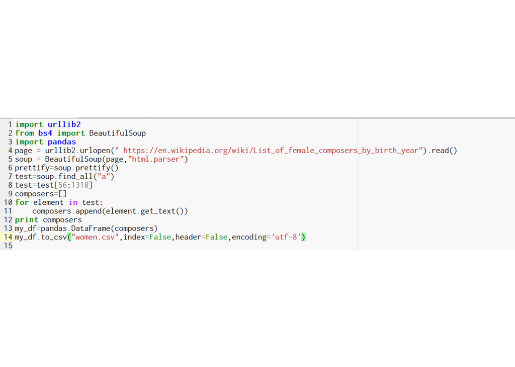

```r
img01 <- readPNG("women.png")
grid.raster(img01)
```

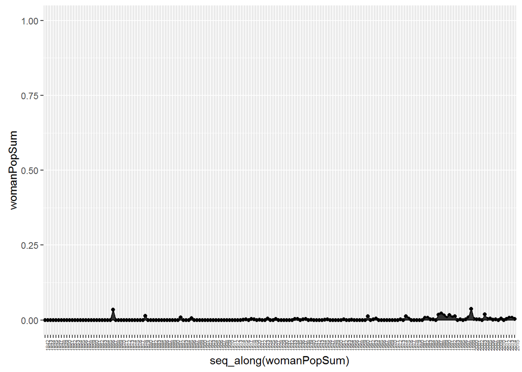

```r
women<- read.csv("women.csv", header = FALSE,encoding="UTF-8")
woman1.0=women$V1
woman1.1=strsplit(as.character(woman1.0)," ")
woman1.2=list(rep(0,length(woman1.1)))
for ( i in 1:length(woman1.1)){
  if (length(woman1.1[[i]])>1){
    woman1.2[i]=paste(woman1.1[[i]][length(woman1.1[[i]])],paste(woman1.1[[i]][1:length(woman1.1[[i]])-1], collapse=" "),sep=", ")
  }
}
l=c()
for ( i in 1:length(woman1.2)){
  l=c(l,which(woman1.2[i]==popScoreComposerComplete$composers))
}

woman=popScoreComposerComplete$composers[l]
womanPop=popScoreComposerComplete[l,]
womanPopSum=colSums(womanPop[2:175])
qplot(seq_along(womanPopSum),womanPopSum)+geom_line()+ylim(0,1)+geom_area(colour="black")+ scale_x_discrete(labels =(1842:2015))+ theme(axis.text.x = element_text(angle = 90,size=5, hjust = 1))
```

```r
l=c()
for ( i in 1:length(woman1.2)){
  l=c(l,which(woman1.2[i]==contem$composers))
}
contempWomen=contem$composers[l]
```

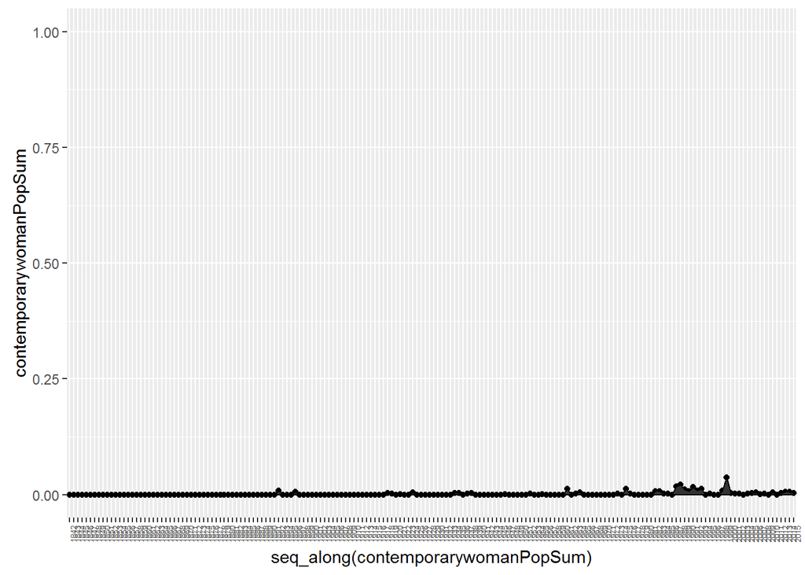

```r
l=c()
for ( i in 1:length(contempWomen)){
  l=c(l,which(contempWomen[i]==contem$composers))
}

contemporarywoman=contem$composers[l]
contemporarywomanPop=contem[l,]
contemporarywomanPopSum=colSums(contemporarywomanPop[2:175])
qplot(seq_along(contemporarywomanPopSum),contemporarywomanPopSum)+geom_line()+ylim(0,1)+geom_area(colour="black")+ scale_x_discrete(labels =(1842:2015))+ theme(axis.text.x = element_text(angle = 90,size=5, hjust = 1))
```

Thee graph shows the sad fact that there is not much increase in the proportion of the number of women composers over time nor the overall proportion graph nor the contemporary composers proportion graph.

### the global impressionist trend

I got a list of impressionist composers from WikiPedia https://en.wikipedia.org/wiki/Category:Impressionist_composers

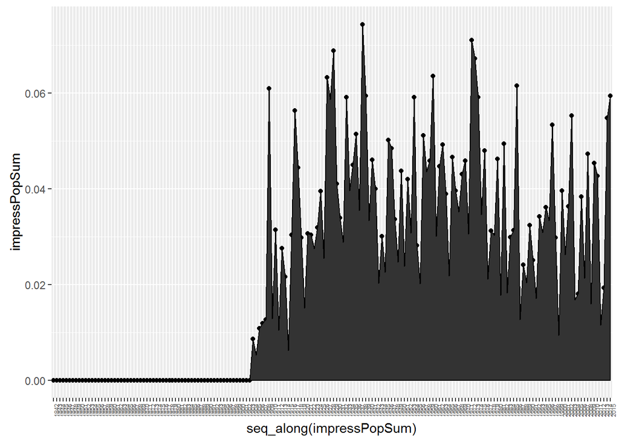

```r
impresComp=c("Benoit, Paul","Debussy, Claude", "Fanelli, Ernest", "Hughes, Herbert", "Ravel, Maurice", "Respighi, Ottorino", "Salzedo, Carlos")
l=c()
for ( i in 1:length(impresComp)){
  l=c(l,which(impresComp[i]==popScoreComposerComplete$composers))
}
impress=popScoreComposerComplete$composers[l]
impressPop=popScoreComposerComplete[l,]
impressPopSum=colSums(impressPop[2:175])
qplot(seq_along(impressPopSum),impressPopSum)+geom_line()+geom_area(colour="black")+ scale_x_discrete(labels =(1842:2015))+ theme(axis.text.x = element_text(angle = 90,size=5, hjust = 1))
```

frech impressionist painers https://en.wikipedia.org/wiki/Category:French_Impressionist_painters

#### art from MoMA

```r
require(dplyr)
MoMA=read.csv("MoMA.csv",header=TRUE,encoding = "UTF-8")
moma.1=select(MoMA, Nationality, Date)[1:98578,]
moma.1$Date.1=as.numeric(gsub("([0-9]+).*$", "\\1", moma.1$Date))
moma.1=na.omit(moma.1)
moma.1=select(moma.1,Nationality, Date.1)
#write.csv(moma.1,"momaSmall.csv")
```

```r
moma.1=read.csv("momaSmall.csv",row.names=1)
moma.1=filter(moma.1, Date.1>=1929)

test=unique(moma.1$Date.1)

test=sort(test)
tyear=rep(0,length(test))
soviet=rep(0,length(test))
american=rep(0,length(test))
germanAustria=rep(0,length(test))
french=rep(0,length(test))
italian=rep(0,length(test))
asianLatin=rep(0,length(test))

psoviet=rep(0,length(test))
pamerican=rep(0,length(test))
pgermanAustria=rep(0,length(test))
pfrench=rep(0,length(test))
pitalian=rep(0,length(test))
pasianLatin=rep(0,length(test))

for ( i in 1:length(test)){
  tyear[i]=unlist(nrow(subset(moma.1,Date.1==test[i])))
  american[i]=length(grep("American",subset(moma.1,Date.1==test[i])$Nationality))+length(grep("USA",subset(moma.1,Date.1==test[i])$Nationality))
  pamerican[i]=as.numeric(american[i])/as.numeric(tyear[i])

   soviet[i]=length(grep("Russian",subset(moma.1,Date.1==test[i])$Nationality))
   #+length(grep("Czech",subset(moma.1,Date.1==test[i])$Nationality))+length(grep("Hungarian",subset(moma.1,Date.1==test[i])$Nationality))+length(grep("Polish",subset(moma.1,Date.1==test[i])$Nationality))+length(grep("Lithuanian",subset(moma.1,Date.1==test[i])$Nationality))+length(grep("Romanian",subset(moma.1,Date.1==test[i])$Nationality))+length(grep("Slovenian",subset(moma.1,Date.1==test[i])$Nationality))+length(grep("Ukrainian",subset(moma.1,Date.1==test[i])$Nationality))+length(grep("Bulgarian",subset(moma.1,Date.1==test[i])$Nationality))
  psoviet[i]=as.numeric(soviet[i])/as.numeric(tyear[i])

  germanAustria[i]=length(grep("German",subset(moma.1,Date.1==test[i])$Nationality))
  #+length(grep("Austrian",subset(moma.1,Date.1==test[i])$Nationality))
  pgermanAustria[i]=as.numeric(germanAustria[i])/as.numeric(tyear[i])

  french[i]=length(grep("French",subset(moma.1,Date.1==test[i])$Nationality))
  pfrench[i]=as.numeric(french[i])/as.numeric(tyear[i])

  italian[i]=length(grep("Italian",subset(moma.1,Date.1==test[i])$Nationality))
  pitalian[i]=as.numeric(italian[i])/as.numeric(tyear[i])

   asianLatin[i]=length(grep("Chinese",subset(moma.1,Date.1==test[i])$Nationality))+length(grep("Taiwanese",subset(moma.1,Date.1==test[i])$Nationality))+length(grep("Japanese",subset(moma.1,Date.1==test[i])$Nationality))+length(grep("Indian",subset(moma.1,Date.1==test[i])$Nationality))+length(grep("Turkish",subset(moma.1,Date.1==test[i])$Nationality))+length(grep("Brazilian",subset(moma.1,Date.1==test[i])$Nationality))+length(grep("Argentine",subset(moma.1,Date.1==test[i])$Nationality))
  pasianLatin[i]=as.numeric(asianLatin[i])/as.numeric(tyear[i])
}
```

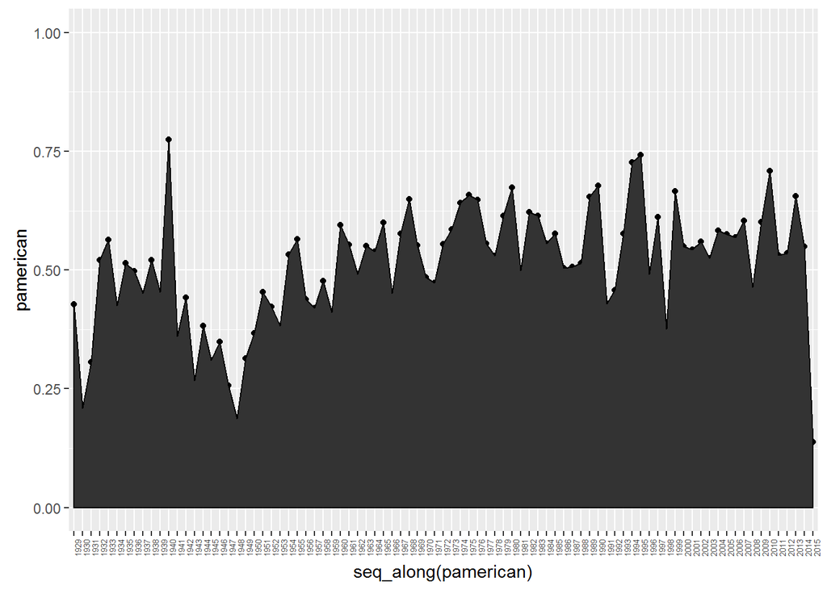

```r
qplot(seq_along(pamerican),pamerican)+geom_line()+ylim(0,1)+geom_area(colour="black")+ scale_x_discrete(labels =(1929:2015))+ theme(axis.text.x = element_text(angle = 90,size=5, hjust = 1))
```

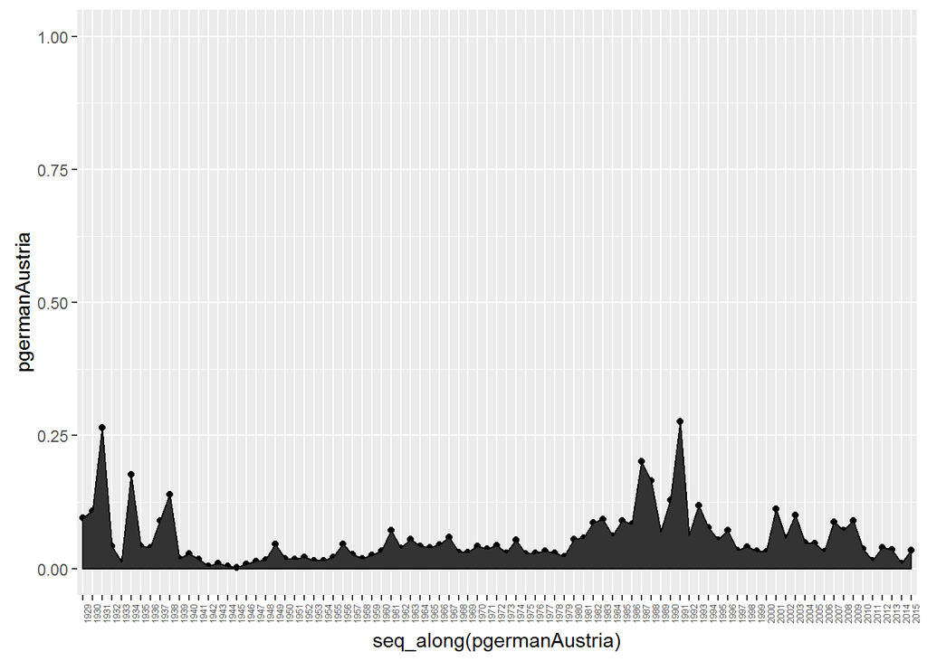

```r
qplot(seq_along(pgermanAustria),pgermanAustria)+geom_line()+ylim(0,1)+geom_area(colour="black")+ scale_x_discrete(labels =(1929:2015))+ theme(axis.text.x = element_text(angle = 90,size=5, hjust = 1))
```

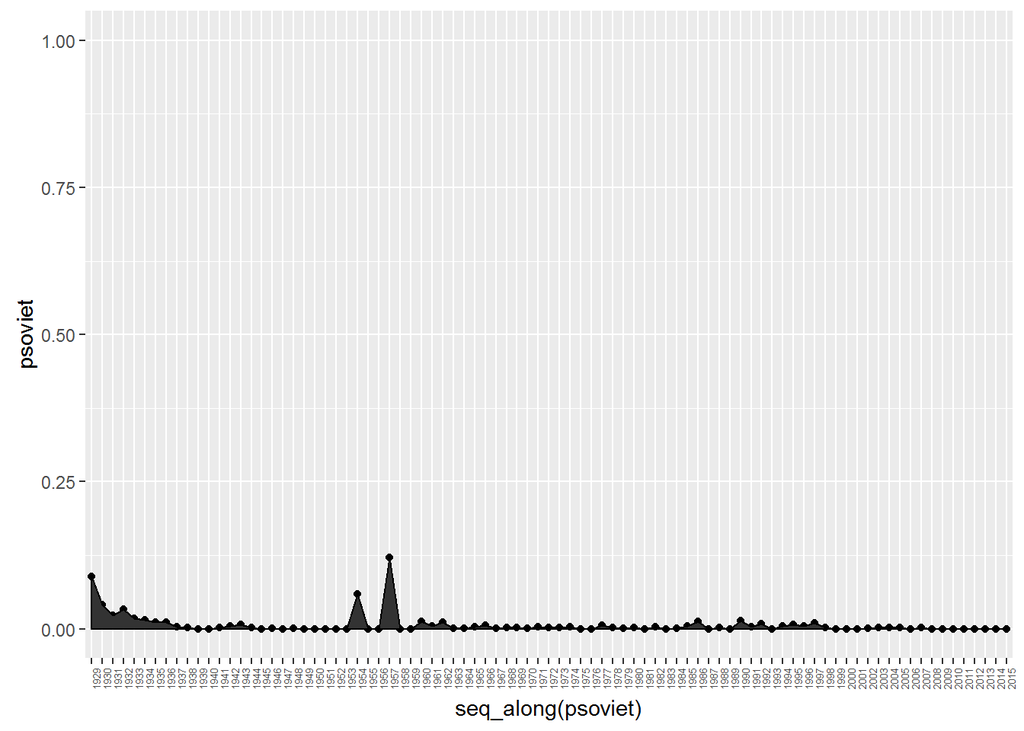

```r
qplot(seq_along(psoviet),psoviet)+geom_line()+ylim(0,1)+geom_area(colour="black")+ scale_x_discrete(labels =(1929:2015))+ theme(axis.text.x = element_text(angle = 90,size=5, hjust = 1))
```